# Symbiodiniaceae community dynamics in *Pocillopora* colonies from Uva Island reef during 2014-2016

Ana Palacio-Castro

March 29, 2020

This file analyzes the changes in S/H cell ratio (bleaching and symbiont shuffling) in *Pocillopora* spp.: * 29 colonies were sampled in 2014 (Before ENSO), 2015 (during a 1st peak of heat) and 2016 (after a 2nd peak of heat) * These samples were collected at Uva Island, Gulf of Chiriquí, Panama.

```r
# Libraries
    library(plyr)
    library(tidyverse) # install.packages('tidyverse')
    # library(devtools)  # install.packages("devtools")
    # devtools::install_github("jrcunning/steponeR")
    library(steponeR)
    library(scales)
    library(gridExtra)
    library(lme4)
    library(lmerTest)
    library(multcomp)
    library(emmeans)

# Default ggplot settings
    ggthe_bw<-theme_bw() +
      theme(plot.background=element_blank(),
          panel.grid.major.y = element_blank(),
          panel.grid.major.x = element_blank(),
          panel.grid.minor.x = element_blank(),
          panel.grid.minor.y = element_blank(),
          axis.line = element_line(colour = "black"),
          legend.box.background = element_rect(),
          panel.background =element_rect(fill = NA, color = "black")
          )
```

## 1. Symbiont to host (S/H) cell ratio and *Durusdinium* proportion

Get the raw data for all *Pocillopora* samples applying R.Cunning steponeR function

- Get list of plate files to read data
- Calculate the ratios
- Export results

```r
Pdam.plates <- list.files(path="data", pattern=".csv", full.names=T)
Pdam.plates
```

```
##  [1] "data/Chi-Pdam_Plate2.csv"   "data/Chi-Pdam_Plate3.csv"
##  [3] "data/Chi-Pdam_Plate4.csv"   "data/Chi-Pdam_Plate5.csv"
##  [5] "data/Chi-Pdam_Plate6.csv"   "data/Gal-Pdam_Plate13.csv"
##  [7] "data/Gal-Pdam_Plate14.csv"  "data/Gal-Pdam_Plate15.csv"
##  [9] "data/Gal-Pdam_Plate16.csv"  "data/Gal1_Dprobes_data.csv"
## [11] "data/Pan-Pdam_Plate10.csv"  "data/Pan-Pdam_Plate7.csv"
## [13] "data/Pan-Pdam_Plate8.csv"   "data/Pan-Pdam_Plate9.csv"
## [15] "data/Pdam_Plate11-Deep.csv"
```

```r
Pdam.Out <- steponeR(files=Pdam.plates, target.ratios=c("C.Pdam", "D.Pdam"),
                     fluor.norm=list(C=3.798, D=0, Pdam=5.416),
                     copy.number=list(C=9, D=1, Pdam=3),
                     ploidy=list(C=1, D=1, Pdam=2),
                     extract=list(C=0.813, D=0.813, Pdam=0.982))

# Target ratio results
Pdam<-Pdam.Out$result
```

Get colony and year information from sample labels

```r
# Parse sample names, times, treatments, colonies, plates
    sample.year <- rbind.fill(lapply(strsplit(as.character(Pdam$Sample.Name), split="_"),
     function(X) data.frame(t(X))))
        colnames(sample.year) <- c("Spp", "Colony","Year")
        Pdam <- cbind(sample.year, Pdam[,-1])

# Keep unique sample ID to check reruns
    Pdam$Sample<-paste(Pdam$Year,Pdam$Colony, sep="_")
    Pdam$ID<-paste(Pdam$Sample,Pdam$File.Name, sep=".")
```

Calculate total S/H ratio and D/C ratio and Proportion of *Durusdinium* in each sample

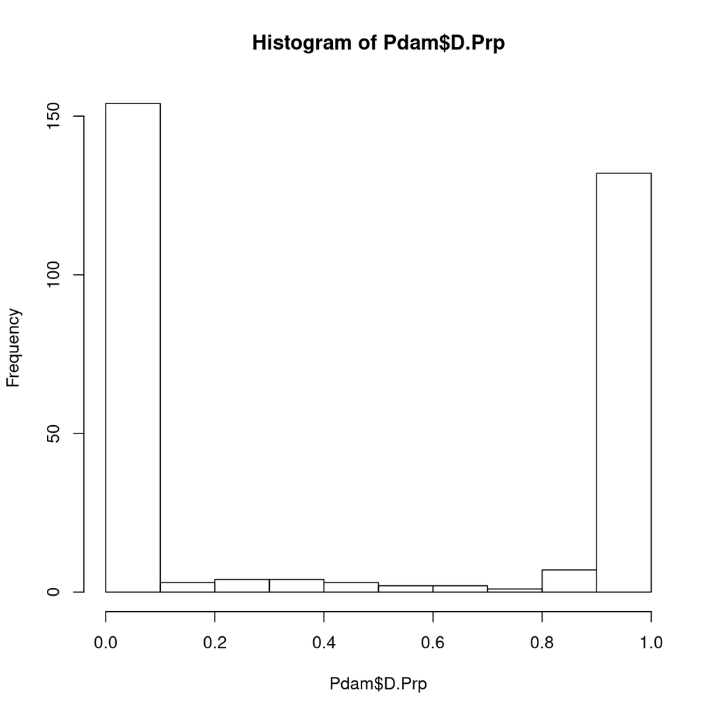

```r
# 0. If Clade only detected in one technical replicate, set its ratio to NA (becomes zero)
  Pdam$C.Pdam[which(Pdam$C.reps==1)] <- NA
  Pdam$D.Pdam[which(Pdam$D.reps==1)] <- NA

# 1. Rename cols and make NA=0
  colnames(Pdam)[which(colnames(Pdam) %in% c("C.Pdam", "D.Pdam" ))] <- c("C.SH", "D.SH")

  Pdam$C.SH[is.na(Pdam$C.SH)] <- 0
  Pdam$D.SH[is.na(Pdam$D.SH)] <- 0

  Pdam <- Pdam[, c("Colony", "Year", "C.SH", "D.SH","Sample", "ID")]

# 2. Get the ratios and log 10
  # Total ratio
  Pdam$tot.SH <- Pdam$C.SH + Pdam$D.SH
  Pdam$logTot.SH <- log10(Pdam$tot.SH )

  # C ratio
  Pdam$logC.SH <- log10(Pdam$C.SH)

  # D ratio
  Pdam$logD.SH <- log10(Pdam$D.SH)

  Pdam$logTot.SH[which(Pdam$tot.SH==0)] <- NA
  Pdam$logC.SH[which(Pdam$C.SH==0)] <- NA
  Pdam$logD.SH[which(Pdam$D.SH==0)] <- NA

# Clade Proportion
  # D Proportion
  Pdam$D.Prp<-(Pdam$D.SH/Pdam$tot.SH)
  # C Proportion
  #Pdam$C.Prp<-(Pdam$C.SH/Pdam$tot.SH)

  hist(Pdam$D.Prp)
```

```r
  #Dproportion<-Pdam[(Pdam$D.Prp<0.99 & Pdam$D.Prp>0.01),]
  #hist(Dproportion$D.Prp)
```

**Note**: Most of the colonies are dominated by one symbiont genus. Even proportions of multiple symbionts are rare.

## 2. qPCR Data Cleaning and quality control

```r
 ## 1. Check and remove NTC wells
  ntc <- Pdam[which(Pdam$Colony=="NTC"), ]
  Pdam <- droplevels(Pdam[!rownames(Pdam) %in% rownames(ntc), ])

  ## 2. Check and remove NoHSratio samples
  NoHSratio <- Pdam[which(Pdam$tot.SH==0), ]
  Pdam <- droplevels(Pdam[!rownames(Pdam) %in% rownames(NoHSratio), ])

  ## 3. Chose bw samples ran more than once
  ReRunA <- Pdam[duplicated(Pdam$Sample),]

  n_RunA <- data.frame(table(Pdam$Sample))
  colnames(n_RunA)<-c("Sample","RanA")
  Pdam<-join(Pdam, n_RunA, type = "left")

  DuplicatesA <- Pdam[(Pdam$RanA>1),]

  # Remove bad replicates
  ToRem1<-read.csv("ToRemove10-28-16.csv")  # 11/1/16
  Pdam<-Pdam[!(Pdam$ID %in% ToRem1$ID),]

  n_RunB <- data.frame(table(Pdam$Sample))
  ReRunB <- Pdam[duplicated(Pdam$Sample),]
  colnames(n_RunB)<-c("Sample","RanB")
  Pdam<-join(Pdam, n_RunB, type = "left")

  # List of duplicated samples, should have 0 rows now
  DuplicatesB <- Pdam[(Pdam$RanB>1),]

  # 4. Check and remove samples with high SD or late amplification
  StDe1.5 <- Pdam[which(Pdam$Pdam.CT.sd>1.5), ]
  Pdam<-Pdam[!(Pdam$ID %in% StDe1.5$ID),]
# End of qPCR data cleaning
```

## 3. Field/sample information

Get collection information and select only samples from Uva Island that were sampled in 2014, 2015 and 2016

```r
# 1. Labeling and Factors

  ## Import treatment info from Field file and mortality / ITS2 / ORF data
  Info<-read.csv("SampleInfo.csv", header=TRUE)
  Mortality<-read.csv("MortalityData.csv", header=TRUE)
  Mortality$ITS_2<-factor(Mortality$ITS_2, level=c("C1d", "C1b-c", "D1"))


  ## Merge SH ratios and sample info
      Pdam<-join(Pdam, Info, by = "Sample",
                type = "left", match = "all")
      #summary(Pdam)

# 2. Uva Data
      # Write how many years a colony was sampled
      Years <- data.frame(table(Pdam$Colony))
      colnames(Years)<-c("Colony","Times")
      Pdam<-join(Pdam, Years, type = "left")
  # Select data only from Uva Island
      data.Uva<-Pdam[which(Pdam$Location=="Uva Island"), ]
  # Select colonies that were sampled three times (2014, 2015 and 2016)
      data.Uva<-data.Uva[which(data.Uva$Times>2),]
  # Remove "Ross" samples (colony in deep location (~50feet), not Uva reef)
  # and 259 as well as 264 that were mislabeled in at least one of the sampling points
      data.Uva<-filter(data.Uva, Colony!="Ross")
      data.Uva<-filter(data.Uva, Colony!="259-1")
      data.Uva<-filter(data.Uva, Colony!="264-1")

      data.Uva<-data.Uva[,c("Colony","Year.2","C.SH","D.SH","tot.SH",
                            "logTot.SH","D.Prp", "logC.SH", "logD.SH",
                            "Year","Sample", "Reef", "Spp", "Depht")]
      data.Uva$Year<-factor(data.Uva$Year, levels=c("14", "15", "16"))
      data.Uva$Colony<-factor(data.Uva$Colony)

    #summary(data.Uva)

  #3. Merge SH ratios and mortality info
      data.Uva<-join(data.Uva, Mortality, by = "Sample",
                type = "left", match = "all")
      summary(data.Uva)
```

```
##      Colony       Year.2          C.SH               D.SH
##  256-1  : 3   Min.   :2014   Min.   :0.000000   Min.   :0.00000
##  257-1  : 3   1st Qu.:2014   1st Qu.:0.000000   1st Qu.:0.00000
##  260-1  : 3   Median :2015   Median :0.003005   Median :0.01442
##  262-1  : 3   Mean   :2015   Mean   :0.019174   Mean   :0.02071
##  278-1  : 3   3rd Qu.:2016   3rd Qu.:0.011841   3rd Qu.:0.03001
##  284-1  : 3   Max.   :2016   Max.   :0.690021   Max.   :0.18875
##  (Other):69
##      tot.SH          logTot.SH           D.Prp           logC.SH
##  Min.   :0.00146   Min.   :-2.8356   Min.   :0.0000   Min.   :-5.0627
##  1st Qu.:0.01294   1st Qu.:-1.8888   1st Qu.:0.0000   1st Qu.:-2.5001
##  Median :0.02266   Median :-1.6448   Median :0.8620   Median :-2.0971
##  Mean   :0.03988   Mean   :-1.6539   Mean   :0.5411   Mean   :-2.1808
##  3rd Qu.:0.03579   3rd Qu.:-1.4463   3rd Qu.:1.0000   3rd Qu.:-1.7015
##  Max.   :0.69002   Max.   :-0.1611   Max.   :1.0000   Max.   :-0.1611
##                                                       NA's   :32
##     logD.SH        Year       Sample                              Reef
##  Min.   :-5.7262   14:29   Length:87          Coral Collection Point:36
##  1st Qu.:-1.8381   15:29   Class :character   Shallow Millepora     :18
##  Median :-1.6245   16:29   Mode  :character   M.intrincata Shallow  :12
##  Mean   :-2.0059                              Ridley Rock Shallow   : 9
##  3rd Qu.:-1.4640                              Gardineroseris city   : 6
##  Max.   :-0.7241                              Bw Gard City and 4x5  : 3
##  NA's   :29                                   (Other)               : 3
##     Spp         Depht              Mortality    ID_Glynn   ID_Palacio
##  P.dam:51   Min.   : 9.00   Almost total: 7   P. cap:12   P. dam:24
##  P.eff: 0   1st Qu.:15.00   No          :71   P. dam:27   P. eyd: 6
##  P.ele:36   Median :17.00   Partial     : 9   P. ver:48   P. ver:57
##  P.eyd: 0   Mean   :17.79
##  P.mea: 0   3rd Qu.:20.00
##  P.ver: 0   Max.   :32.00
##
##      ORF       ITS_2
##  Type_1:69   C1d  :18
##  Type_3:18   C1b-c:20
##              D1   :49
##
##
##
##
```

```r
      data.Uva$Mortality<-factor(data.Uva$Mortality, levels =
                              c("No", "Partial", "Almost total"))
```

### ORF types versus morphological ID

```r
  # Summary ID  *Pocillopora* by Glynn
  Summary_ID_Glynn<-data.Uva %>%
        group_by(Year.2, ORF, ID_Glynn) %>%
        dplyr::summarise(total.count=n())
  Summary_ID_Glynn
```

| Year.2 | ORF | ID_Glynn | total.count |
| --- | --- | --- | --- |
| 2014 | Type_1 | P. cap | 4 |
| 2014 | Type_1 | P. dam | 3 |
| 2014 | Type_1 | P. ver | 16 |
| 2014 | Type_3 | P. dam | 6 |
| 2015 | Type_1 | P. cap | 4 |
| 2015 | Type_1 | P. dam | 3 |
| 2015 | Type_1 | P. ver | 16 |
| 2015 | Type_3 | P. dam | 6 |
| 2016 | Type_1 | P. cap | 4 |
| 2016 | Type_1 | P. dam | 3 |

[output cut: 2 more lines]

```r
  # Summary ID  *Pocillopora* by Palacio
  Summary_ID_Glynn<-data.Uva %>%
        group_by(Year.2, ORF, ID_Palacio) %>%
        dplyr::summarise(total.count=n())
  Summary_ID_Glynn
```

| Year.2 | ORF | ID_Palacio | total.count |
| --- | --- | --- | --- |
| 2014 | Type_1 | P. dam | 2 |
| 2014 | Type_1 | P. eyd | 2 |
| 2014 | Type_1 | P. ver | 19 |
| 2014 | Type_3 | P. dam | 6 |
| 2015 | Type_1 | P. dam | 2 |
| 2015 | Type_1 | P. eyd | 2 |
| 2015 | Type_1 | P. ver | 19 |
| 2015 | Type_3 | P. dam | 6 |
| 2016 | Type_1 | P. dam | 2 |
| 2016 | Type_1 | P. eyd | 2 |

[output cut: 2 more lines]

## 4. Community classification by genera presence/dominance

### Symbiodiniaceae genera detected in the samples (Only-C, Only-D, Mixed communities)

```r
# Add a column for the genera detected in each sample using qPCR
  data.Uva$Community<-NULL
  data.Uva$Community[which(data.Uva$D.Prp>=0)] <- "Mixed"
  data.Uva$Community[which(data.Uva$D.Prp==0)] <- "Cladocopium-only"
  data.Uva$Community[which(data.Uva$D.Prp==1)] <- "Durusdinium-only"

  data.Uva$Community<-factor(as.character(data.Uva$Community),
                         levels=c("Cladocopium-only", "Mixed", "Durusdinium-only"))

# Summary genera *Pocillopora*
  Summary_Community<-data.Uva %>%
        group_by(Year.2, Community) %>%
        dplyr::summarise(total.count=n())
  Summary_Community
```

| Year.2 | Community | total.count |
| --- | --- | --- |
| 2014 | Cladocopium-only | 9 |
| 2014 | Mixed | 12 |
| 2014 | Durusdinium-only | 8 |
| 2015 | Cladocopium-only | 13 |
| 2015 | Mixed | 6 |
| 2015 | Durusdinium-only | 10 |
| 2016 | Cladocopium-only | 7 |
| 2016 | Mixed | 8 |
| 2016 | Durusdinium-only | 14 |

```r
  # Summary genera detected by ORF type
  Summary_Community<-data.Uva %>%
        group_by(ORF, Year.2, Community) %>%
        dplyr::summarise(total.count=n())
  Summary_Community
```

| ORF | Year.2 | Community | total.count |
| --- | --- | --- | --- |
| Type_1 | 2014 | Cladocopium-only | 3 |
| Type_1 | 2014 | Mixed | 12 |
| Type_1 | 2014 | Durusdinium-only | 8 |
| Type_1 | 2015 | Cladocopium-only | 7 |
| Type_1 | 2015 | Mixed | 6 |
| Type_1 | 2015 | Durusdinium-only | 10 |
| Type_1 | 2016 | Cladocopium-only | 1 |
| Type_1 | 2016 | Mixed | 8 |
| Type_1 | 2016 | Durusdinium-only | 14 |
| Type_3 | 2014 | Cladocopium-only | 6 |

[output cut: 2 more lines]

### Dominant Symbiodiniaceae genus in each sample (C-dominated, D-dominated)

In general, *Pocillopora* colonies are dominated by one Symbiodiniaceae type that accounts for more than 80-90 of the symbiont community. However, sometimes intermediate proportions are common when the symbiont community is transitioning from being dominated by one algal type to another (e.g. during heat stress).

```r
 # Add a column for the dominant genus
  data.Uva$DominantCommunity<-NULL
  data.Uva$DominantCommunity[which(data.Uva$D.Prp>=0.45)] <- "Durusdinium-dominated"
  data.Uva$DominantCommunity[which(data.Uva$D.Prp<0.45)] <- "Cladocopium-dominated"

  data.Uva$DominantCommunity<-factor(as.character(data.Uva$DominantCommunity),
                              levels=c("Cladocopium-dominated","Durusdinium-dominated"))

  # Summary dominant genera *Pocillopora*
  Summary_Community2<-data.Uva %>%
        group_by(Year.2, DominantCommunity) %>%
        dplyr::summarise(total.count=n())
  Summary_Community2
```

| Year.2 | DominantCommunity | total.count |
| --- | --- | --- |
| 2014 | Cladocopium-dominated | 15 |
| 2014 | Durusdinium-dominated | 14 |
| 2015 | Cladocopium-dominated | 15 |
| 2015 | Durusdinium-dominated | 14 |
| 2016 | Cladocopium-dominated | 8 |
| 2016 | Durusdinium-dominated | 21 |

```r
  # Summary dominant genera by ORF type
  Summary_Community3<-data.Uva %>%
        group_by(ORF, Year.2, DominantCommunity) %>%
        dplyr::summarise(total.count=n())
  Summary_Community3
```

| ORF | Year.2 | DominantCommunity | total.count |
| --- | --- | --- | --- |
| Type_1 | 2014 | Cladocopium-dominated | 9 |
| Type_1 | 2014 | Durusdinium-dominated | 14 |
| Type_1 | 2015 | Cladocopium-dominated | 9 |
| Type_1 | 2015 | Durusdinium-dominated | 14 |
| Type_1 | 2016 | Cladocopium-dominated | 2 |
| Type_1 | 2016 | Durusdinium-dominated | 21 |
| Type_3 | 2014 | Cladocopium-dominated | 6 |
| Type_3 | 2015 | Cladocopium-dominated | 6 |
| Type_3 | 2016 | Cladocopium-dominated | 6 |

Set initial (2014) and final (2016) communities for each colony

```r
  data.Uva$ITS_2<-factor(data.Uva$ITS_2, level=c("C1b-c", "C1d", "D1"))
  # Sub set Aug 2014,  Aug 2015 and April 2016 samples
  D2014.data<-subset(data.Uva, Year.2==2014)
  D2014.data<-D2014.data[,c("Colony","D.Prp","Community","DominantCommunity", "ITS_2")]
  colnames(D2014.data)<-(c("Colony","D14.D.Prp","D14Community", "D14Dominant", "ITS2_14"))
  data.Uva<-left_join(data.Uva, D2014.data, by=c("Colony")) # Add initial community to all samples

  D2016.data<-subset(data.Uva, Year.2==2016) # D1a under control temperature
  D2016.data<-D2016.data[, c("Colony","D.Prp","Community","DominantCommunity", "ITS_2")]
  colnames(D2016.data)<-(c("Colony","D16.D.Prp","D16Community", "D16Dominant",  "ITS2_16"))
  data.Uva<-left_join(data.Uva, D2016.data, by=c("Colony")) # Add final community to all samples
```

# A. Initial qPCR BASED analysis (No ITS2 or ORF information included)…

Skip to 5b for complete paper results. Section A was my mental process to analyze the symbiont data that got refined once we got the ITS2 and ORF results (B)

## 5a. Changes in the number of *Pocillopora* colonies dominated by each genus

To test the statistical significance of changes in the number of colonies dominated by *Durusdinium* versus *Cladocopium* we considered inclusion and exclusion of these 2 initially even colonies, and to place them in the D-dominated or C-dominated categories in 2014.

- Fisher test including initially (Aug 2014) even colonies. Both colonies were placed in the D-dominated category. P-value= 0.1064

```r
Input =("
Year    C     D
2014    15   14
2016    8    21
")

Matriz <- as.matrix(read.table(textConnection(Input),
                               header=TRUE,
                               row.names=1))
fisher.test(Matriz,
            alternative="two.sided")
```

```
##
##  Fisher's Exact Test for Count Data
##
## data:  Matriz
## p-value = 0.1064
## alternative hypothesis: true odds ratio is not equal to 1
## 95 percent confidence interval:
##  0.8336155 9.7658946
## sample estimates:
## odds ratio
##   2.760908
```

- Fisher test including initially (Aug 2014) even colonies. One colony was placed in the C-dominated category (D proportion=0.47), while the second one was placed in the D-dominated category (D proportion = 0.50). P-value = 0.06099

```r
Input =("
Year    C     D
2014    16   13
2016    8    21
")

Matriz <- as.matrix(read.table(textConnection(Input),
                               header=TRUE,
                               row.names=1))
fisher.test(Matriz,
            alternative="two.sided")
```

```
##
##  Fisher's Exact Test for Count Data
##
## data:  Matriz
## p-value = 0.06099
## alternative hypothesis: true odds ratio is not equal to 1
## 95 percent confidence interval:
##   0.9556883 11.2396870
## sample estimates:
## odds ratio
##   3.162767
```

- Fisher test removing initially (Aug 2014) even colonies. N=27 colonies instead 29. P-value = 0.09778

```r
Input =("
Year    C     D
2014    15   12
2016    8    19
")

Matriz <- as.matrix(read.table(textConnection(Input),
                               header=TRUE,
                               row.names=1))
fisher.test(Matriz,
            alternative="two.sided")
```

```
##
##  Fisher's Exact Test for Count Data
##
## data:  Matriz
## p-value = 0.09778
## alternative hypothesis: true odds ratio is not equal to 1
## 95 percent confidence interval:
##   0.848568 10.659493
## sample estimates:
## odds ratio
##   2.906792
```

- Fisher test including initially (Aug 2014) even colonies. Both colonies placed in the C-dominated category (D proportion=0.47, colony 267; and 0.50, colony 269). p-value = 0.03295

```r
Input =("
Year    C     D
2014    17   12
2016    8    21
")

Matriz <- as.matrix(read.table(textConnection(Input),
                               header=TRUE,
                               row.names=1))
fisher.test(Matriz,
            alternative="two.sided")
```

```
##
##  Fisher's Exact Test for Count Data
##
## data:  Matriz
## p-value = 0.03295
## alternative hypothesis: true odds ratio is not equal to 1
## 95 percent confidence interval:
##   1.094473 13.006776
## sample estimates:
## odds ratio
##   3.629777
```

## 6a. Changes in colony proportions based on detected genera (qPCR)

- Based on detected Symbiodiniaceae genera in 2014 (qPCR)

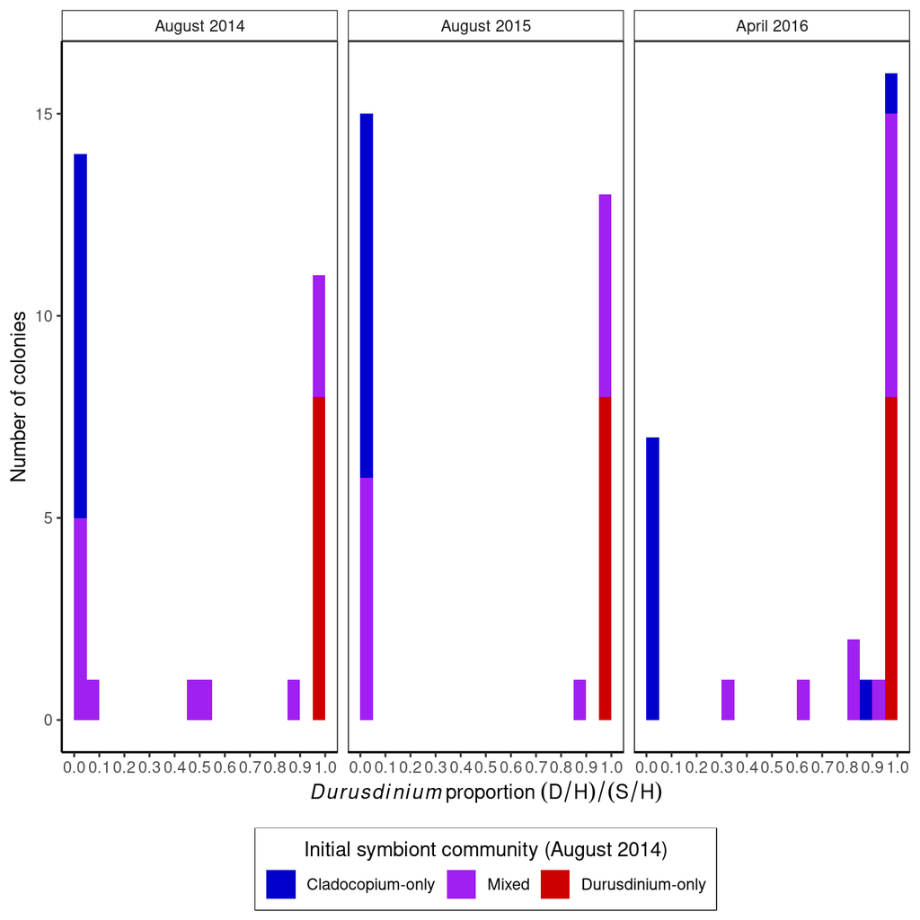

```r
Histo_Dprop <- ggplot(data.Uva, aes (D.Prp , fill=(D14Community))) + ggthe_bw +
  geom_histogram(binwidth = 0.05, boundary=0) +
  facet_grid(~Year.2, labeller = labeller(Year.2=c(
                `2014` = "August 2014", `2015` = "August 2015", `2016` = "April 2016"))) +
  scale_fill_manual(values=c("blue3","purple", "red3"),
                    guide = guide_legend(title.position = "top", nrow = 1),
                    name = "Initial symbiont community (August 2014)",
                    labels=c("Cladocopium-only", "Mixed", "Durusdinium-only")) +
    scale_x_continuous(name= expression(
    italic(Durusdinium)~proportion~(D/H)/(S/H)),
                     breaks=(seq(0,1,by=0.1))) +
    scale_y_continuous((name= "Number of colonies"),
                     breaks=seq(0,15,by=5)) +
    theme(legend.position="bottom",
        legend.title.align=0.5,
        strip.background =element_rect(fill=NA))
Histo_Dprop
```

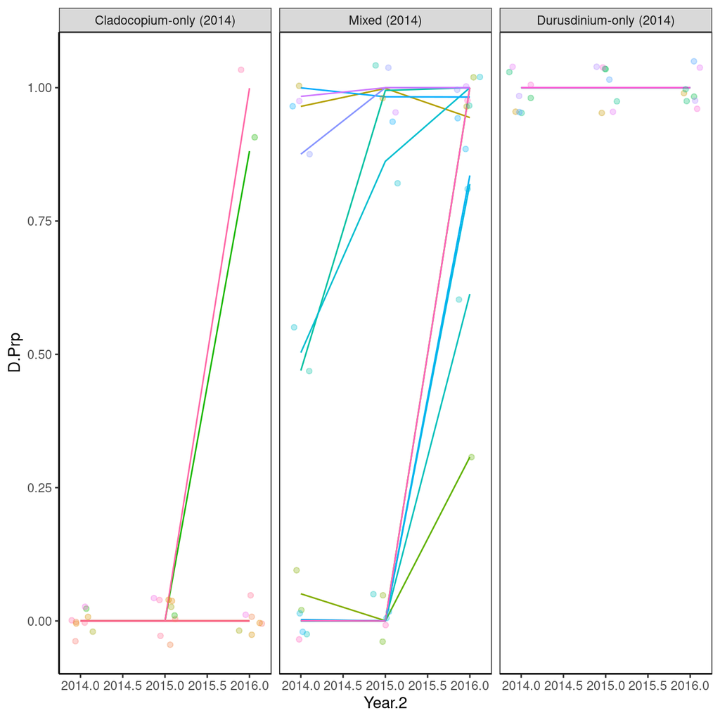

```r
Traject_Proportion_Facet <- ggplot (data.Uva) +
   ggthe_bw +
    geom_line(aes (x=Year.2, D.Prp, colour=factor(Colony)))+
    facet_wrap(~D14Community, labeller = labeller(
    D14Community=c(`Cladocopium-only` = "Cladocopium-only (2014)",
                   `Mixed` = "Mixed (2014)",
                   `Durusdinium-only` = "Durusdinium-only (2014)"))) +
    geom_jitter(aes(Year.2, D.Prp, colour=factor(Colony)), alpha=0.3,
              height = 0.05, width = 0.15) +
    #labs(x = "Año del muestreo", y = "Durusdinium Proportion") +
    theme(legend.position="none")
Traject_Proportion_Facet
```

### Figure Not used: qPCR and colony proportion by dominant community

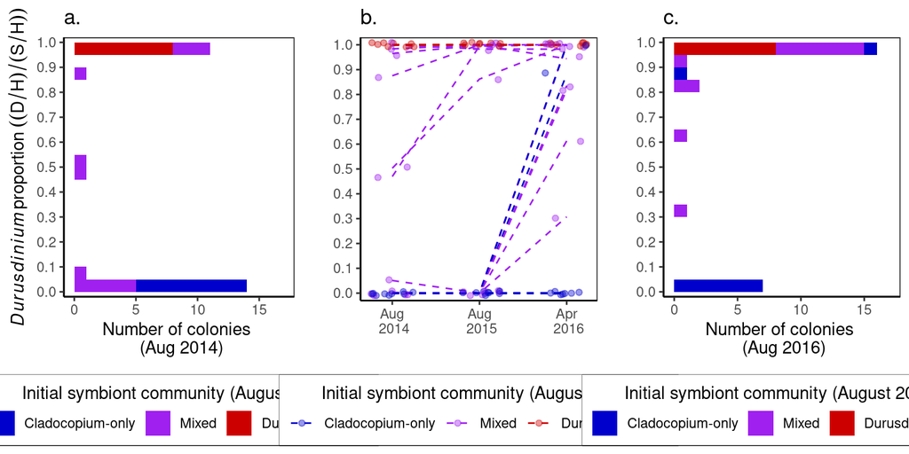

```r
Histo2014_Dprop <- ggplot(data.Uva[which(data.Uva$Year.2==2014), ], aes (D.Prp , fill=(D14Community))) +
      ggthe_bw + coord_flip()+ ggtitle("a.")+
      geom_histogram(binwidth = 0.05, boundary=0) +
      scale_fill_manual(values=c("blue3","purple", "red3"),
                        guide = guide_legend(title.position = "top", nrow = 1),
                        name = "Initial symbiont community (August 2014)",
                        labels=c("Cladocopium-only", "Mixed", "Durusdinium-only")) +
      scale_x_continuous(name= expression(
                        italic(Durusdinium)~proportion~((D/H)/(S/H))),
                        breaks=(seq(0,1,by=0.1)),
                        expand=c(0.01,0.01)) +
      scale_y_continuous((name= "Number of colonies \n (Aug 2014)"),
                        limits = c(0,17),
                        breaks=seq(0,15,by=5)) +
      theme(legend.position="bottom",
            legend.title.align=0.5,
            strip.background =element_rect(fill=NA))
#Histo2014_Dprop

Histo2016_Dprop <- ggplot(data.Uva[which(data.Uva$Year.2==2016), ], aes (D.Prp , fill=(D14Community))) +
      ggthe_bw + coord_flip()+ ggtitle("c.")+
      geom_histogram(binwidth = 0.05, boundary=0) +
      scale_fill_manual(values=c("blue3","purple", "red3"),
                        guide = guide_legend(title.position = "top", nrow = 1),
                        name = "Initial symbiont community (August 2014)",
                        labels=c("Cladocopium-only", "Mixed", "Durusdinium-only")) +
      scale_x_continuous(name="",
                        breaks=(seq(0,1,by=0.1)),
                        expand=c(0.01,0.01)) +
      scale_y_continuous((name= "Number of colonies \n (Aug 2016)"),
                        limits = c(0,17),
                        breaks=seq(0,15,by=5)) +
      theme(legend.position="bottom",
            legend.title.align=0.5,
            strip.background =element_rect(fill=NA))
#Histo2016_Dprop

Traject_Proportion<- ggplot(data.Uva, aes (x=Year.2, y=D.Prp , colour=(D14Community), group=(Colony))) + ggthe_bw + ggtitle("b.") +
  geom_line(linetype=2) +
  geom_jitter(height = 0.01, width = 0.25, alpha=0.4) +

  scale_colour_manual(values=c("blue3","purple", "red3"),
                    guide = guide_legend(title.position = "top", nrow = 1),
                    name = "Initial symbiont community (August 2014)",
                    labels=c("Cladocopium-only", "Mixed", "Durusdinium-only")) +
  scale_x_continuous(name="",
                         breaks = c(2014, 2015, 2016),
                         labels = c(" Aug \n 2014", " Aug \n 2015", " Apr \n 2016")) +
  scale_y_continuous((name= ""),
                     breaks=seq(0,1,by=0.1),
                     expand=c(0.01,0.01)) +

  theme(legend.position="bottom",
        legend.title.align=0.5,
        strip.background =element_rect(fill=NA))
#Traject_Proportion

Figure_2<-grid.arrange(Histo2014_Dprop,Traject_Proportion, Histo2016_Dprop,
nrow=1, widths=c(3/9, 3/9, 3/9))
```

```r
# ggsave(file="Outputs/Figure_2qPCR.svg", plot=Figure_2, width=7, height=4)
```

## 7a. Changes in total Symbiodiniaceae abundance (bleaching): qPCR

### Based on initial (2014) community

```r
SH_2014Co<-lmerTest::lmer(logTot.SH ~ Year * D14Community + (1|Colony), data=data.Uva)
    summary(SH_2014Co)
```

```
## Linear mixed model fit by REML. t-tests use Satterthwaite's method [
## lmerModLmerTest]
## Formula: logTot.SH ~ Year * D14Community + (1 | Colony)
##    Data: data.Uva
##
## REML criterion at convergence: 83.7
##
## Scaled residuals:
##     Min      1Q  Median      3Q     Max
## -2.6538 -0.5202 -0.1347  0.3700  2.9430
##
## Random effects:
##  Groups   Name        Variance Std.Dev.
##  Colony   (Intercept) 0.03036  0.1742
##  Residual             0.10764  0.3281
## Number of obs: 87, groups:  Colony, 29
##
## Fixed effects:
##                                     Estimate Std. Error      df t value
## (Intercept)                          -1.6402     0.1238 71.1153 -13.246
## Year15                               -0.4132     0.1547 52.0000  -2.672
## Year16                               -0.5536     0.1547 52.0000  -3.579
## D14CommunityMixed                    -0.0137     0.1638 71.1153  -0.084
## D14CommunityDurusdinium-only          0.1232     0.1805 71.1153   0.682
## Year15:D14CommunityMixed              0.7731     0.2046 52.0000   3.778
## Year16:D14CommunityMixed              0.6960     0.2046 52.0000   3.402
## Year15:D14CommunityDurusdinium-only   0.4584     0.2255 52.0000   2.033
## Year16:D14CommunityDurusdinium-only   0.3869     0.2255 52.0000   1.716
##                                     Pr(>|t|)
## (Intercept)                          < 2e-16 ***
## Year15                              0.010053 *
## Year16                              0.000756 ***
## D14CommunityMixed                   0.933599
## D14CommunityDurusdinium-only        0.497283
## Year15:D14CommunityMixed            0.000408 ***
## Year16:D14CommunityMixed            0.001294 **
## Year15:D14CommunityDurusdinium-only 0.047152 *
## Year16:D14CommunityDurusdinium-only 0.092125 .
## ---
## Signif. codes:  0 '***' 0.001 '**' 0.01 '*' 0.05 '.' 0.1 ' ' 1
##
## Correlation of Fixed Effects:
##             (Intr) Year15 Year16 D14CmM D14CD- Y15:D14CM Y16:D14CM Y15:D14CD
## Year15      -0.624
## Year16      -0.624  0.500
## D14CmmntyMx -0.756  0.472  0.472
## D14CmmntyD- -0.686  0.428  0.428  0.519
## Yr15:D14CmM  0.472 -0.756 -0.378 -0.624 -0.324
## Yr16:D14CmM  0.472 -0.378 -0.756 -0.624 -0.324  0.500
## Yr15:D14CD-  0.428 -0.686 -0.343 -0.324 -0.624  0.519     0.259
## Yr16:D14CD-  0.428 -0.343 -0.686 -0.324 -0.624  0.259     0.519     0.500
```

```r
    #step(SH_2014Co)

    SH.emmc<-emmeans(SH_2014Co, ~Year*D14Community)
    SH_groups<-multcomp::cld(SH.emmc)
    SH_groups<-SH_groups[order(
                SH_groups$Year, SH_groups$D14Community),]
    SH_groups
```

|  | Year | D14Community | emmean | SE | df | lower.CL | upper.CL | .group |
| --- | --- | --- | --- | --- | --- | --- | --- | --- |
| 1 | 14 | Cladocopium-only | -1.640249 | 0.1238281 | 71.11527 | -1.887149 | -1.393350 | 23 |
| 4 | 14 | Mixed | -1.653946 | 0.1072383 | 71.11527 | -1.867767 | -1.440125 | 23 |
| 7 | 14 | Durusdinium-only | -1.517093 | 0.1313395 | 71.11527 | -1.778969 | -1.255217 | 23 |
| 2 | 15 | Cladocopium-only | -2.053456 | 0.1238281 | 71.11527 | -2.300355 | -1.806557 | 12 |
| 5 | 15 | Mixed | -1.294094 | 0.1072383 | 71.11527 | -1.507915 | -1.080273 | 3 |
| 8 | 15 | Durusdinium-only | -1.471908 | 0.1313395 | 71.11527 | -1.733784 | -1.210032 | 3 |
| 3 | 16 | Cladocopium-only | -2.193834 | 0.1238281 | 71.11527 | -2.440733 | -1.946934 | 1 |
| 6 | 16 | Mixed | -1.511519 | 0.1072383 | 71.11527 | -1.725340 | -1.297698 | 3 |
| 9 | 16 | Durusdinium-only | -1.683811 | 0.1313395 | 71.11527 | -1.945687 | -1.421935 | 123 |

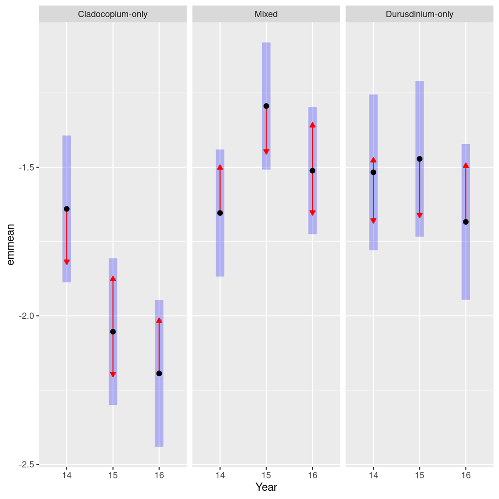

```r
    plot(emmeans(SH_2014Co, ~Year|~D14Community), comparisons = TRUE) +
      coord_flip(xlim = NULL, ylim = NULL, expand = TRUE) + facet_wrap(~D14Community)
```

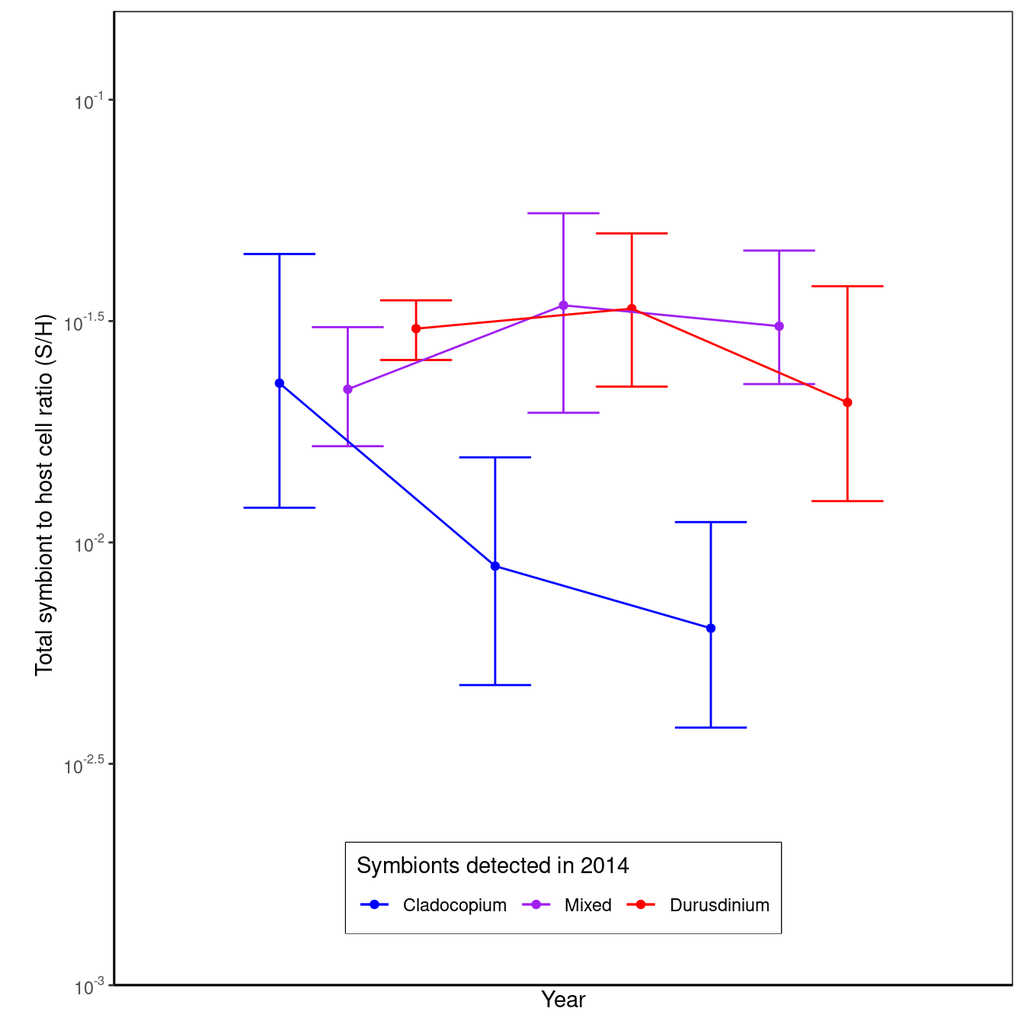

```r
SH_2014Com <- ggplot(data.Uva, aes (Year.2, logTot.SH, colour=factor(D14Community))) +  ggthe_bw +
      stat_summary(fun.data = "mean_cl_boot",geom = "errorbar", width = 1,
                       position=position_dodge(width=0.95))+
      stat_summary(fun.data = "mean_cl_boot",geom = "point",
                       position=position_dodge(width=0.95))+
      stat_summary(fun.y=mean, geom="line", position=position_dodge(width=0.95)) +

      scale_colour_manual(values=c("blue","purple", "red"),
                            guide = guide_legend(title.position = "top", nrow = 1),
                            name = "Symbionts detected in 2014",
                            labels=c("Cladocopium", "Mixed", "Durusdinium"))+
      theme(legend.position=c(0.5,0.1),
            strip.background =element_rect(fill="white")) +
      scale_y_continuous(limits = c(-3, -0.8),
                name="\n Total symbiont to host cell ratio (S/H)",
                labels = (math_format(10^.x)),
                expand = c(0.0, 0)) +
      scale_x_discrete(name="Year")
SH_2014Com
```

### Based on current community

```r
SH_Community<-lmerTest::lmer(logTot.SH ~ Year * Community + (1|Colony), data=data.Uva)
    summary(SH_Community)
```

```
## Linear mixed model fit by REML. t-tests use Satterthwaite's method [
## lmerModLmerTest]
## Formula: logTot.SH ~ Year * Community + (1 | Colony)
##    Data: data.Uva
##
## REML criterion at convergence: 91.3
##
## Scaled residuals:
##     Min      1Q  Median      3Q     Max
## -2.3973 -0.5171 -0.0987  0.3905  4.0587
##
## Random effects:
##  Groups   Name        Variance Std.Dev.
##  Colony   (Intercept) 0.02404  0.1550
##  Residual             0.12526  0.3539
## Number of obs: 87, groups:  Colony, 29
##
## Fixed effects:
##                                  Estimate Std. Error       df t value Pr(>|t|)
## (Intercept)                      -1.60009    0.12804 76.71004 -12.497  < 2e-16
## Year15                           -0.20778    0.15540 49.73821  -1.337 0.187280
## Year16                           -0.71036    0.17979 47.25498  -3.951 0.000258
## CommunityMixed                   -0.09453    0.16829 77.96039  -0.562 0.575910
## CommunityDurusdinium-only         0.09882    0.18645 77.17622   0.530 0.597641
## Year15:CommunityMixed             0.58170    0.24003 54.72489   2.423 0.018708
## Year16:CommunityMixed             0.81742    0.24650 54.96060   3.316 0.001622
## Year15:CommunityDurusdinium-only  0.27313    0.22958 47.93526   1.190 0.240035
## Year16:CommunityDurusdinium-only  0.60594    0.24059 49.84010   2.519 0.015039
##
## (Intercept)                      ***
## Year15
## Year16                           ***
## CommunityMixed
## CommunityDurusdinium-only
## Year15:CommunityMixed            *
## Year16:CommunityMixed            **
## Year15:CommunityDurusdinium-only
## Year16:CommunityDurusdinium-only *
## ---
## Signif. codes:  0 '***' 0.001 '**' 0.01 '*' 0.05 '.' 0.1 ' ' 1
##
## Correlation of Fixed Effects:
##             (Intr) Year15 Year16 CmmntM CmmnD- Y15:CM Y16:CM Y15:CD
## Year15      -0.733
## Year16      -0.602  0.497
## CommuntyMxd -0.754  0.576  0.457
## CmmntyDrsd- -0.686  0.504  0.414  0.524
## Yr15:CmmntM  0.472 -0.658 -0.322 -0.628 -0.326
## Yr16:CmmntM  0.459 -0.365 -0.740 -0.608 -0.318  0.412
## Yr15:CmmnD-  0.496 -0.677 -0.337 -0.383 -0.717  0.440  0.243
## Yr16:CmmnD-  0.451 -0.369 -0.747 -0.326 -0.682  0.240  0.543  0.541
```

```r
    #step(SH_Community)

    SH.emmc<-emmeans(SH_Community, ~Year*Community)
    SH_groups<-multcomp::cld(SH.emmc)
    SH_groups<-SH_groups[order(
                SH_groups$Year, SH_groups$Community),]
    SH_groups
```

|  | Year | Community | emmean | SE | df | lower.CL | upper.CL | .group |
| --- | --- | --- | --- | --- | --- | --- | --- | --- |
| 1 | 14 | Cladocopium-only | -1.600085 | 0.1289710 | 77.12210 | -1.856893 | -1.343278 | 2 |
| 4 | 14 | Mixed | -1.694620 | 0.1116431 | 77.85210 | -1.916891 | -1.472349 | 2 |
| 7 | 14 | Durusdinium-only | -1.501267 | 0.1367656 | 77.56003 | -1.773571 | -1.228963 | 2 |
| 2 | 15 | Cladocopium-only | -1.807862 | 0.1072407 | 76.77109 | -2.021416 | -1.594308 | 12 |
| 5 | 15 | Mixed | -1.320693 | 0.1578114 | 77.83192 | -1.634882 | -1.006504 | 2 |
| 8 | 15 | Durusdinium-only | -1.435913 | 0.1223503 | 77.04322 | -1.679541 | -1.192285 | 2 |
| 3 | 16 | Cladocopium-only | -2.310448 | 0.1462059 | 77.68972 | -2.601539 | -2.019356 | 1 |
| 6 | 16 | Mixed | -1.587562 | 0.1366113 | 77.94484 | -1.859537 | -1.315587 | 2 |
| 9 | 16 | Durusdinium-only | -1.605684 | 0.1033367 | 76.62366 | -1.811470 | -1.399899 | 2 |

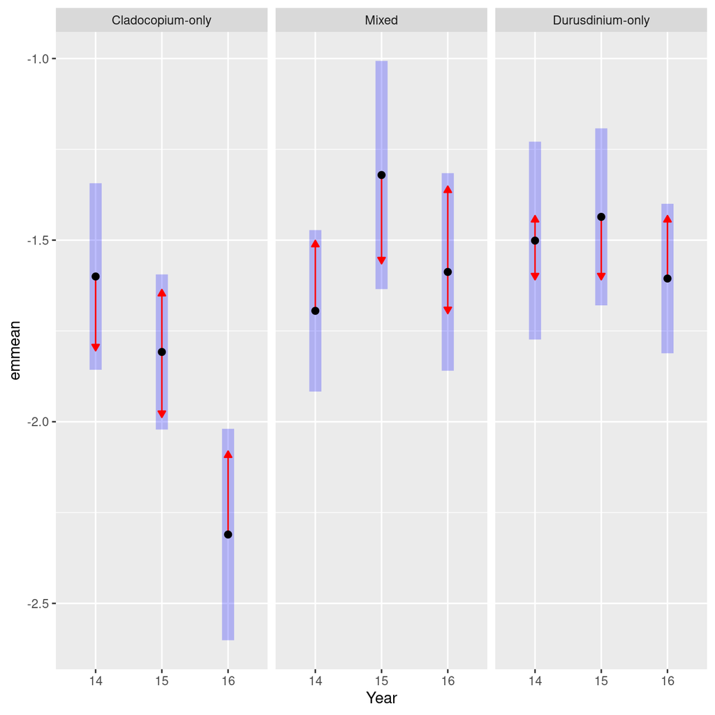

```r
    #write.csv(SH_groups,"SH_groupsB.csv")

plot(emmeans(SH_Community, ~Year|~Community), comparisons = TRUE) +
      coord_flip(xlim = NULL, ylim = NULL, expand = TRUE) + facet_wrap(~Community)
```

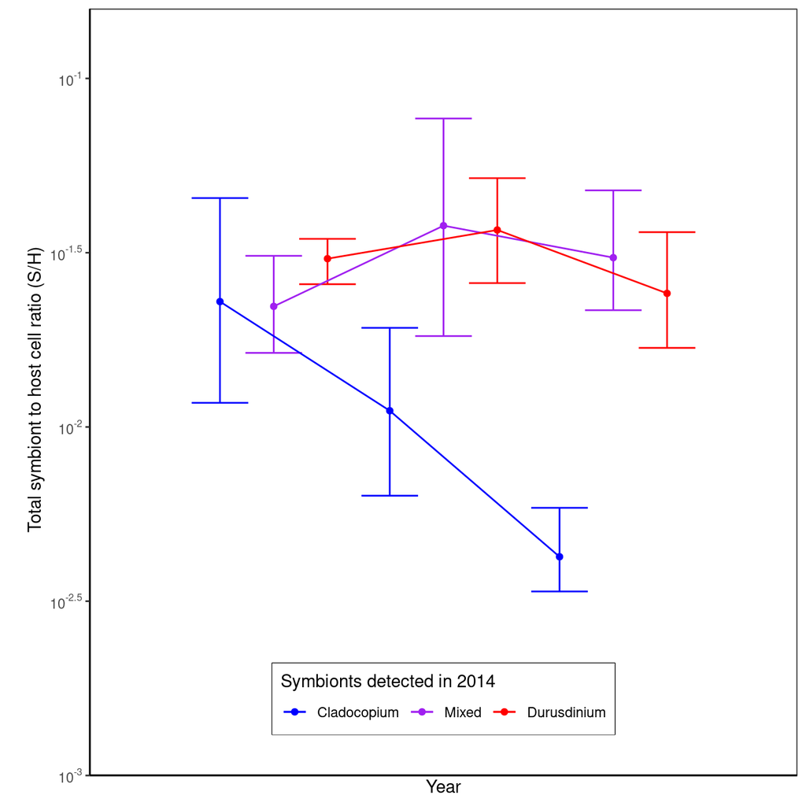

```r
SH_Com <- ggplot(data.Uva, aes (Year.2, logTot.SH, colour=factor(Community))) +  ggthe_bw +
      stat_summary(fun.data = "mean_cl_boot",geom = "errorbar", width = 1,
                       position=position_dodge(width=0.95))+
      stat_summary(fun.data = "mean_cl_boot",geom = "point",
                       position=position_dodge(width=0.95))+
      stat_summary(fun.y=mean, geom="line", position=position_dodge(width=0.95)) +

      scale_colour_manual(values=c("blue","purple", "red"),
                            guide = guide_legend(title.position = "top", nrow = 1),
                            name = "Symbionts detected in 2014",
                            labels=c("Cladocopium", "Mixed", "Durusdinium"))+
      theme(legend.position=c(0.5,0.1),
            strip.background =element_rect(fill="white")) +
      scale_y_continuous(limits = c(-3, -0.8),
                name="\n Total symbiont to host cell ratio (S/H)",
                labels = (math_format(10^.x)),
                expand = c(0.0, 0)) +
      scale_x_discrete(name="Year")
SH_Com
```

```r
anova(SH_2014Co, SH_Community)
```

|  | npar | AIC | BIC | logLik | deviance | Chisq | Df | Pr(>Chisq) |
| --- | --- | --- | --- | --- | --- | --- | --- | --- |
| SH_2014Co | 11 | 83.25516 | 110.3801 | -30.62758 | 61.25516 | NA | NA | NA |
| SH_Community | 11 | 91.84909 | 118.9741 | -34.92454 | 69.84909 | 0 | 0 | NA |

### Considering initial and current symbiont community: Figure 3: qPCR

```r
SH_Communities<-lmerTest::lmer(logTot.SH ~ Year * D14Community * Community + (1|Colony), data=data.Uva)
    summary(SH_Communities)
```

```
## Linear mixed model fit by REML. t-tests use Satterthwaite's method [
## lmerModLmerTest]
## Formula: logTot.SH ~ Year * D14Community * Community + (1 | Colony)
##    Data: data.Uva
##
## REML criterion at convergence: 81.6
##
## Scaled residuals:
##      Min       1Q   Median       3Q      Max
## -2.73407 -0.48463 -0.06579  0.35339  2.91935
##
## Random effects:
##  Groups   Name        Variance Std.Dev.
##  Colony   (Intercept) 0.02179  0.1476
##  Residual             0.11026  0.3320
## Number of obs: 87, groups:  Colony, 29
##
## Fixed effects:
##                                     Estimate Std. Error      df t value
## (Intercept)                          -1.6402     0.1211 70.1550 -13.541
## Year15                               -0.4132     0.1565 47.2363  -2.640
## Year16                               -0.7093     0.1688 50.6884  -4.202
## D14CommunityMixed                    -0.7146     0.3265 73.0936  -2.189
## D14CommunityDurusdinium-only         -0.6296     0.3928 72.9975  -1.603
## CommunityMixed                        0.7009     0.2845 70.5547   2.464
## CommunityDurusdinium-only             0.7527     0.3508 70.9827   2.146
## Year15:D14CommunityMixed              1.5019     0.3806 64.8657   3.946
## Year16:D14CommunityMixed              0.8259     0.2396 53.9251   3.447
## Year15:D14CommunityDurusdinium-only   1.2674     0.5110 61.4046   2.480
## Year16:D14CommunityDurusdinium-only   0.5426     0.2368 48.9752   2.292
## Year15:CommunityMixed                -0.7379     0.3653 70.6556  -2.020
## Year15:CommunityDurusdinium-only     -0.8090     0.4572 64.7392  -1.770
##                                     Pr(>|t|)
## (Intercept)                          < 2e-16 ***
## Year15                              0.011206 *
## Year16                              0.000107 ***
## D14CommunityMixed                   0.031805 *
## D14CommunityDurusdinium-only        0.113266
## CommunityMixed                      0.016178 *
## CommunityDurusdinium-only           0.035332 *
## Year15:D14CommunityMixed            0.000198 ***
## Year16:D14CommunityMixed            0.001108 **
## Year15:D14CommunityDurusdinium-only 0.015876 *
## Year16:D14CommunityDurusdinium-only 0.026258 *
## Year15:CommunityMixed               0.047162 *
## Year15:CommunityDurusdinium-only    0.081500 .
## ---
## Signif. codes:  0 '***' 0.001 '**' 0.01 '*' 0.05 '.' 0.1 ' ' 1
## fit warnings:
## fixed-effect model matrix is rank deficient so dropping 14 columns / coefficients
```

```r
    #step(SH_Communities)

    SH.emmc<-emmeans(SH_Communities, ~Year*D14Community*Community)
    SH_groups<-cld(SH.emmc)
    SH_groups<-as.data.frame(SH_groups[complete.cases(SH_groups),])
    SH_groups<-SH_groups[order(SH_groups$Year,
                               SH_groups$D14Community,
                               SH_groups$Community),]
    SH_groups
```

|  | Year | D14Community | Community | emmean | SE | df | lower.CL | upper.CL | .group |
| --- | --- | --- | --- | --- | --- | --- | --- | --- | --- |
| 1 | 14 | Cladocopium-only | Cladocopium-only | -1.640249 | 0.1211285 | 70.36842 | -1.881810 | -1.3986884 | 23 |
| 13 | 14 | Mixed | Mixed | -1.653946 | 0.1049004 | 70.36842 | -1.863144 | -1.4447481 | 23 |
| 25 | 14 | Durusdinium-only | Durusdinium-only | -1.517093 | 0.1284762 | 70.36842 | -1.773307 | -1.2608791 | 23 |
| 2 | 15 | Cladocopium-only | Cladocopium-only | -2.053456 | 0.1211285 | 70.36842 | -2.295017 | -1.8118949 | 12 |
| 5 | 15 | Mixed | Cladocopium-only | -1.266232 | 0.1815951 | 73.82315 | -1.628082 | -0.9043813 | 23 |
| 14 | 15 | Mixed | Mixed | -1.303193 | 0.1482385 | 73.98995 | -1.598565 | -1.0078207 | 3 |
| 23 | 15 | Mixed | Durusdinium-only | -1.322519 | 0.2568718 | 73.11015 | -1.834451 | -0.8105877 | 123 |
| 26 | 15 | Durusdinium-only | Durusdinium-only | -1.471908 | 0.1284762 | 70.36842 | -1.728122 | -1.2156939 | 23 |
| 3 | 16 | Cladocopium-only | Cladocopium-only | -2.349596 | 0.1373003 | 72.72049 | -2.623252 | -2.0759387 | 1 |
| 12 | 16 | Cladocopium-only | Mixed | -1.648666 | 0.2566477 | 73.07364 | -2.160156 | -1.1371769 | 123 |

[output cut: 3 more lines]

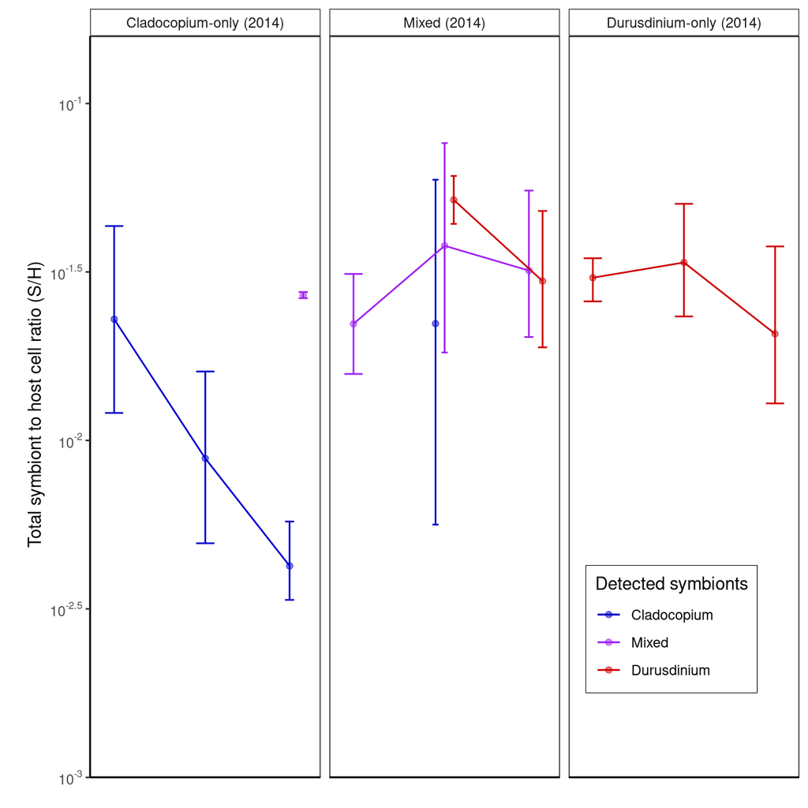

```r
    #write.csv(SH_groups,"SH_Communities_multicomp.csv")

SH_Comties <- ggplot(data.Uva, aes (Year.2, logTot.SH, colour=factor(Community))) + ggthe_bw+

      facet_grid(~D14Community, labeller = labeller(D14Community=c(
                      `Cladocopium-only` = "Cladocopium-only (2014)",
                      `Mixed` = "Mixed (2014)",
                      `Durusdinium-only` = "Durusdinium-only (2014)"))) +

      stat_summary(fun.data = "mean_cl_boot",geom = "errorbar", width = 0.2, position=position_dodge(width=0.3))+
      stat_summary(fun.data = "mean_cl_boot",geom = "point", position=position_dodge(width=0.3), alpha=0.5)+
      stat_summary(fun.y=mean, geom="line", position=position_dodge(width=0.3)) +

      scale_colour_manual(values=c("blue3","purple", "red3"),
                        guide = guide_legend(title.position = "top", nrow = 3),
                        name = "Detected symbionts",
                        labels=c("Cladocopium", "Mixed", "Durusdinium"))+
      theme(legend.position=c(0.82,0.2),
            legend.box.background = element_rect(),
            strip.background =element_rect(fill="white"))+

      scale_y_continuous(limits = c(-3, -0.8),
            name="\n Total symbiont to host cell ratio (S/H)",
            labels = (math_format(10^.x)),
            expand = c(0.0, 0)) +
      scale_x_continuous(name="",
                         breaks = c(14, 15, 16),
                         labels = c(" Aug \n 2014", " Aug \n 2015", " Apr \n 2016"))
SH_Comties
```

```r
#ggsave(file="Figure_3.svg", plot=SH_Comties, width=6, height=4)
```

## 8a. Changes in *Cladocopium* abundance

```r
CH_Com <- ggplot(data.Uva, aes (Year.2, logC.SH, colour=factor(DominantCommunity))) + ggthe_bw+ ggtitle("a.")+
  #geom_point()+

      stat_summary(fun.data = "mean_cl_boot",geom = "errorbar", width = 0.2, position=position_dodge(width=0.3))+
      stat_summary(fun.data = "mean_cl_boot",geom = "point", position=position_dodge(width=0.3), alpha=0.5)+
      stat_summary(fun.y=mean, geom="line", position=position_dodge(width=0.3)) +

      scale_colour_manual(values=c("blue3","purple", "red3"),
                        guide = guide_legend(title.position = "top", nrow = 3),
                        name = "Detected symbionts",
                        labels=c("Cladocopium", "Mixed", "Durusdinium"))+
      theme(legend.position=c(0.82,0.8),
            legend.box.background = element_rect(),
            strip.background =element_rect(fill="white"))+

      scale_y_continuous(limits = c(-3, -0.7),
            name="\n Cladocopium to host cell ratio (C/H)",
            labels = (math_format(10^.x)),
            expand = c(0.0, 0)) +
      scale_x_continuous(name="",
                         breaks = c(2014, 2015, 2016),
                         labels = c(" ", " ", " "))
#CH_Com

CH_Com2<-CH_Com + facet_grid(~D14Dominant, labeller = labeller(D14Dominant=c(
                   `Cladocopium-dominated` = "Cladocopium- \n dominated (2014)",
                   `Durusdinium-dominated` = "Durusdinium- \n dominated (2014)")))


CH<-lmer(logC.SH ~ Year* Community* D14Dominant + (1|Colony), data=data.Uva)
    summary(CH)
```

```
## Linear mixed model fit by REML. t-tests use Satterthwaite's method [
## lmerModLmerTest]
## Formula: logC.SH ~ Year * Community * D14Dominant + (1 | Colony)
##    Data: data.Uva
##
## REML criterion at convergence: 113.6
##
## Scaled residuals:
##      Min       1Q   Median       3Q      Max
## -2.70311 -0.36865 -0.09556  0.50582  1.89250
##
## Random effects:
##  Groups   Name        Variance Std.Dev.
##  Colony   (Intercept) 0.1182   0.3438
##  Residual             0.4032   0.6350
## Number of obs: 55, groups:  Colony, 21
##
## Fixed effects:
##                                         Estimate Std. Error       df t value
## (Intercept)                             -1.54068    0.23810 44.78323  -6.471
## Year15                                  -0.25625    0.28031 26.58185  -0.914
## Year16                                  -0.73614    0.32339 24.71137  -2.276
## CommunityMixed                          -0.32887    0.37022 44.99572  -0.888
## D14DominantDurusdinium-dominated        -1.09559    0.41353 43.96389  -2.649
## Year15:CommunityMixed                    0.59388    0.61658 32.70059   0.963
## Year16:CommunityMixed                   -0.03386    0.50241 28.81910  -0.067
## Year15:D14DominantDurusdinium-dominated -0.54917    0.68606 30.91184  -0.800
## Year16:D14DominantDurusdinium-dominated  0.88798    0.66184 31.43058   1.342
##                                         Pr(>|t|)
## (Intercept)                             6.36e-08 ***
## Year15                                    0.3688
## Year16                                    0.0318 *
## CommunityMixed                            0.3791
## D14DominantDurusdinium-dominated          0.0112 *
## Year15:CommunityMixed                     0.3425
## Year16:CommunityMixed                     0.9467
## Year15:D14DominantDurusdinium-dominated   0.4296
## Year16:D14DominantDurusdinium-dominated   0.1893
## ---
## Signif. codes:  0 '***' 0.001 '**' 0.01 '*' 0.05 '.' 0.1 ' ' 1
##
## Correlation of Fixed Effects:
##             (Intr) Year15 Year16 CmmntM D14DD- Y15:CM Y16:CM Y15:D1
## Year15      -0.715
## Year16      -0.579  0.492
## CommuntyMxd -0.622  0.502  0.369
## D14DmnntDr- -0.019 -0.038  0.003 -0.537
## Yr15:CmmntM  0.318 -0.474 -0.224 -0.512  0.275
## Yr16:CmmntM  0.400 -0.331 -0.659 -0.643  0.345  0.357
## Yr15:D14DD-  0.006  0.017  0.000  0.255 -0.468 -0.705 -0.185
## Yr16:D14DD- -0.021  0.011  0.011  0.308 -0.509 -0.162 -0.437  0.306
## fit warnings:
## fixed-effect model matrix is rank deficient so dropping 3 columns / coefficients
```

```r
    #step(CH)

    CH.emmc<-emmeans(CH, ~Year*Community* D14Dominant)
    CH_groups<-cld(CH.emmc)
    CH_groups<-as.data.frame(CH_groups[complete.cases(CH_groups),])
    CH_groups<-CH_groups[order(CH_groups$Year,CH_groups$D14Dominant, CH_groups$Community),]
    CH_groups
```

|  | Year | Community | D14Dominant | emmean | SE | df | lower.CL | upper.CL | .group |
| --- | --- | --- | --- | --- | --- | --- | --- | --- | --- |
| 1 | 14 | Cladocopium-only | Cladocopium-dominated | -1.540678 | 0.2409458 | 45.21013 | -2.025906 | -1.0554508 | 2 |
| 4 | 14 | Mixed | Cladocopium-dominated | -1.869553 | 0.2952477 | 45.88506 | -2.463896 | -1.2752100 | 12 |
| 10 | 14 | Mixed | Durusdinium-dominated | -2.965142 | 0.2947957 | 42.40551 | -3.559895 | -2.3703884 | 1 |
| 2 | 15 | Cladocopium-only | Cladocopium-dominated | -1.796932 | 0.2003049 | 43.57177 | -2.200732 | -1.3931320 | 12 |
| 5 | 15 | Mixed | Cladocopium-dominated | -1.531922 | 0.5111085 | 45.68777 | -2.560920 | -0.5029243 | 12 |
| 11 | 15 | Mixed | Durusdinium-dominated | -3.176676 | 0.3617028 | 44.83765 | -3.905256 | -2.4480968 | 1 |
| 3 | 16 | Cladocopium-only | Cladocopium-dominated | -2.276820 | 0.2730484 | 45.83331 | -2.826491 | -1.7271478 | 12 |
| 6 | 16 | Mixed | Cladocopium-dominated | -2.639552 | 0.2938213 | 45.92228 | -3.231011 | -2.0480936 | 12 |
| 12 | 16 | Mixed | Durusdinium-dominated | -2.847166 | 0.5089748 | 45.74138 | -3.871835 | -1.8224964 | 12 |

```r
    #write.csv(CH_groups,"CH_groups.csv")
```

## 9a. Changes in *Durusdinium* abundance

```r
DH_Com <- ggplot(data.Uva, aes (Year.2, logD.SH, colour=factor(Community))) +
      ggthe_bw+ ggtitle("b.")+

      stat_summary(fun.data = "mean_cl_boot",geom = "errorbar", width = 0.2, position=position_dodge(width=0.3))+
      stat_summary(fun.data = "mean_cl_boot",geom = "point", position=position_dodge(width=0.3), alpha=0.5)+
      stat_summary(fun.y=mean, geom="line", position=position_dodge(width=0.3)) +

      scale_colour_manual(values=c("purple", "red3"),
                        guide = guide_legend(title.position = "top", nrow = 3),
                        name = "Detected symbionts",
                        labels=c("Mixed", "Durusdinium"))+
      theme(legend.position=c(0.82,0.2),
            legend.box.background = element_rect(),
            strip.background =element_rect(fill="white"))+

      scale_y_continuous(limits = c(-6, -0.7),
            name="\n Durusdinium to host cell ratio (D/H)",
            labels = (math_format(10^.x)),
            expand = c(0.0, 0)) +
      scale_x_continuous(name="",
                         breaks = c(2014, 2015, 2016),
                         labels = c(" Aug \n 2014", " Aug \n 2015", " Apr \n 2016"))

# DH_Com

DH_Com2<-DH_Com + facet_grid(~D14Dominant, labeller = labeller(D14Dominant=c(
                   `Cladocopium-dominated` = "Cladocopium- \n dominated (2014)",
                   `Durusdinium-dominated` = "Durusdinium- \n dominated (2014)")))


DH_LM<-lmer(logD.SH ~ Year* Community* D14Dominant + (1|Colony), data=data.Uva)
    summary(DH_LM)
```

```
## Linear mixed model fit by REML. t-tests use Satterthwaite's method [
## lmerModLmerTest]
## Formula: logD.SH ~ Year * Community * D14Dominant + (1 | Colony)
##    Data: data.Uva
##
## REML criterion at convergence: 66.5
##
## Scaled residuals:
##     Min      1Q  Median      3Q     Max
## -2.0953 -0.5756  0.0079  0.3844  3.6310
##
## Random effects:
##  Groups   Name        Variance Std.Dev.
##  Colony   (Intercept) 0.0000   0.0000
##  Residual             0.1687   0.4107
## Number of obs: 58, groups:  Colony, 22
##
## Fixed effects:
##                                                            Estimate Std. Error
## (Intercept)                                                -4.86573    0.16766
## Year15                                                      0.07049    0.33532
## Year16                                                      3.21459    0.23711
## CommunityDurusdinium-only                                   0.27806    0.50992
## D14DominantDurusdinium-dominated                            3.15614    0.23711
## Year15:CommunityDurusdinium-only                           -0.35506    0.32897
## Year16:CommunityDurusdinium-only                           -0.22094    0.38416
## Year15:D14DominantDurusdinium-dominated                     0.36688    0.42745
## Year16:D14DominantDurusdinium-dominated                    -3.09697    0.41068
## CommunityDurusdinium-only:D14DominantDurusdinium-dominated -0.08557    0.45916
##                                                                  df t value
## (Intercept)                                                48.00000 -29.021
## Year15                                                     48.00000   0.210
## Year16                                                     48.00000  13.557
## CommunityDurusdinium-only                                  48.00000   0.545
## D14DominantDurusdinium-dominated                           48.00000  13.311
## Year15:CommunityDurusdinium-only                           48.00000  -1.079
## Year16:CommunityDurusdinium-only                           48.00000  -0.575
## Year15:D14DominantDurusdinium-dominated                    48.00000   0.858
## Year16:D14DominantDurusdinium-dominated                    48.00000  -7.541
## CommunityDurusdinium-only:D14DominantDurusdinium-dominated 48.00000  -0.186
```

[output cut: 14 more lines]

```
## Correlation of Fixed Effects:
##             (Intr) Year15 Year16 CmmnD- D14DD- Y15:CD Y16:CD Y15:D1 Y16:D1
## Year15      -0.500
## Year16      -0.707  0.354
## CmmntyDrsd-  0.000  0.000 -0.232
## D14DmnntDr- -0.707  0.354  0.500 -0.232
## Yr15:CmmnD-  0.000  0.000  0.000 -0.293  0.360
## Yr16:CmmnD-  0.000  0.000  0.000 -0.753  0.309  0.389
## Yr15:D14DD-  0.392 -0.784 -0.277  0.129 -0.555 -0.500 -0.171
## Yr16:D14DD-  0.408 -0.204 -0.577  0.671 -0.577 -0.208 -0.713  0.320
## CmD-:D14DD-  0.000  0.000  0.258 -0.900  0.000  0.000  0.558  0.000 -0.596
## fit warnings:
## fixed-effect model matrix is rank deficient so dropping 2 columns / coefficients
## optimizer (nloptwrap) convergence code: 0 (OK)
## boundary (singular) fit: see ?isSingular
```

```r
    #step(DH_LM)

    DH.emmc<-emmeans(DH_LM, ~Year*Community* D14Dominant)
    DH_groups<-cld(DH.emmc)
    DH_groups<-as.data.frame(DH_groups[complete.cases(DH_groups),])
    DH_groups<-DH_groups[order(DH_groups$Year,DH_groups$D14Dominant, DH_groups$Community),]
    DH_groups
```

|  | Year | Community | D14Dominant | emmean | SE | df | lower.CL | upper.CL | .group |
| --- | --- | --- | --- | --- | --- | --- | --- | --- | --- |
| 1 | 14 | Mixed | Cladocopium-dominated | -4.865729 | 0.1685911 | 48 | -5.204704 | -4.5267539 | 1 |
| 7 | 14 | Mixed | Durusdinium-dominated | -1.709588 | 0.1706193 | 48 | -2.052641 | -1.3665350 | 2 |
| 10 | 14 | Durusdinium-only | Durusdinium-dominated | -1.517093 | 0.1471244 | 48 | -1.812907 | -1.2212798 | 2 |
| 2 | 15 | Mixed | Cladocopium-dominated | -4.795240 | 0.2999330 | 48 | -5.398296 | -4.1921846 | 1 |
| 8 | 15 | Mixed | Durusdinium-dominated | -1.272218 | 0.2091615 | 48 | -1.692765 | -0.8516707 | 2 |
| 11 | 15 | Durusdinium-only | Durusdinium-dominated | -1.434780 | 0.1308413 | 48 | -1.697854 | -1.1717056 | 2 |
| 3 | 16 | Mixed | Cladocopium-dominated | -1.651141 | 0.1689386 | 48 | -1.990815 | -1.3114672 | 2 |
| 6 | 16 | Durusdinium-only | Cladocopium-dominated | -1.594020 | 0.2969860 | 48 | -2.191150 | -0.9968893 | 2 |
| 9 | 16 | Mixed | Durusdinium-dominated | -1.591969 | 0.2987577 | 48 | -2.192662 | -0.9912765 | 2 |
| 12 | 16 | Durusdinium-only | Durusdinium-dominated | -1.620413 | 0.1191299 | 48 | -1.859940 | -1.3808862 | 2 |

```r
    #write.csv(DH_groups,"DH_groups.csv")
```

### Figure 4: Changes in C/H and D/H

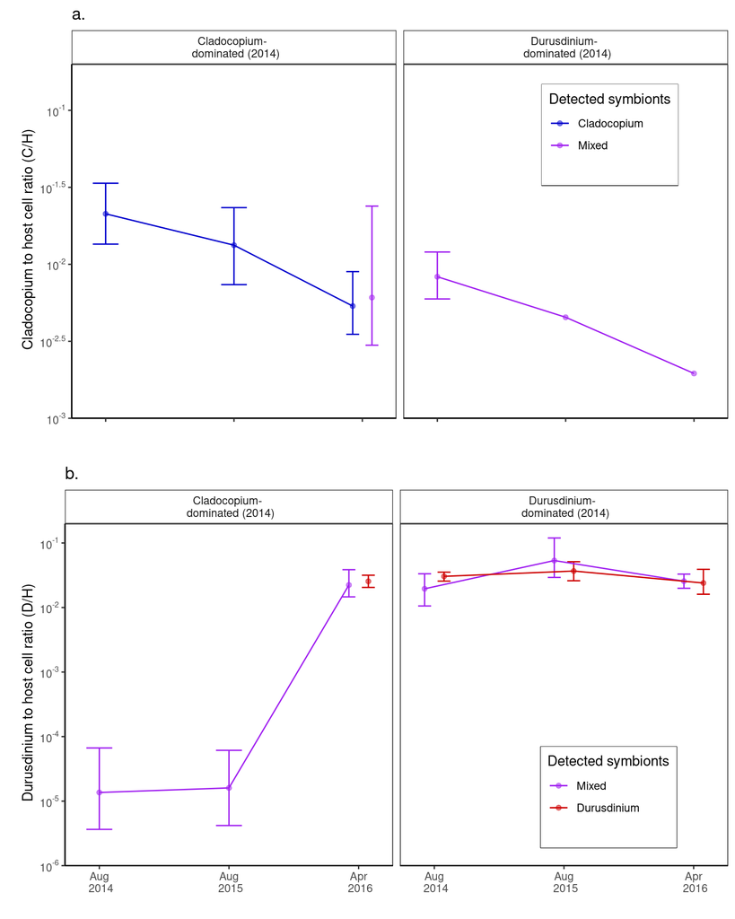

```r
Figure_4<-grid.arrange(CH_Com2, DH_Com2,nrow=2)
```

```r
# ggsave(file="Outputs/Figure_4.svg", plot=Figure_4, width=7, height=4)
```

# Symbiodiniaceae ITS2 type + ORF lineage data analysis

### Added Pocillopora ORF lineage and Symbiodiniaceae ITS2 type hosted in 2014

```r
  #data.Uva$Counts<-paste(data.Uva$DominantCommunity, data.Uva$ORFCommunity, sep = "_")
  data.Uva$ORFCommunity<-paste(data.Uva$ORF, data.Uva$Community, sep = "_")

  data.Uva$ORFCommunity<-factor(data.Uva$ORFCommunity,
                                levels = c("Type_3_Cladocopium-only",
                                           "Type_1_Cladocopium-only",
                                           "Type_1_Mixed",
                                           "Type-1_Durusdinium-only"))

  data.Uva$ORFCommunity2<-paste(data.Uva$ORF,
                              data.Uva$DominantCommunity, sep = "_")
  data.Uva$ORFCommunity2<-as.factor(data.Uva$ORFCommunity2)

  data.Uva$DominantITS2[which(
    (data.Uva$DominantCommunity=="Durusdinium-dominated") &
    (data.Uva$ORF=="Type_1")
      )] <- "D1-dominated"

  data.Uva$DominantITS2[which(
    (data.Uva$DominantCommunity=="Cladocopium-dominated") &
    (data.Uva$ORF=="Type_1")
      )] <- "C1bc-dominated"

    data.Uva$DominantITS2[which(
    (data.Uva$DominantCommunity=="Cladocopium-dominated") &
    (data.Uva$ORF=="Type_3")
      )] <- "C1d-dominated"

   data.Uva$DominantITS2<-as.factor(data.Uva$DominantITS2)

  Summary_Community4<-data.Uva %>%
        group_by(Year.2, DominantITS2) %>%
        dplyr::summarise(total.count=n())
  Summary_Community4
```

| Year.2 | DominantITS2 | total.count |
| --- | --- | --- |
| 2014 | C1bc-dominated | 9 |
| 2014 | C1d-dominated | 6 |
| 2014 | D1-dominated | 14 |
| 2015 | C1bc-dominated | 9 |
| 2015 | C1d-dominated | 6 |
| 2015 | D1-dominated | 14 |
| 2016 | C1bc-dominated | 2 |
| 2016 | C1d-dominated | 6 |
| 2016 | D1-dominated | 21 |

```r
  Summary_Community5<-data.Uva %>%
        group_by(ORF, Year.2, DominantITS2) %>%
        dplyr::summarise(total.count=n())
  Summary_Community5
```

| ORF | Year.2 | DominantITS2 | total.count |
| --- | --- | --- | --- |
| Type_1 | 2014 | C1bc-dominated | 9 |
| Type_1 | 2014 | D1-dominated | 14 |
| Type_1 | 2015 | C1bc-dominated | 9 |
| Type_1 | 2015 | D1-dominated | 14 |
| Type_1 | 2016 | C1bc-dominated | 2 |
| Type_1 | 2016 | D1-dominated | 21 |
| Type_3 | 2014 | C1d-dominated | 6 |
| Type_3 | 2015 | C1d-dominated | 6 |
| Type_3 | 2016 | C1d-dominated | 6 |

## 5b. Changes in the number of colonies dominated by each genus

- Fisher test including initially (Aug 2014) 50/50 colonies. Both colonies placed in the D-dominated category to be conservative.

```r
# Only type 1 colonies (n=23), p-value = 0.03514

Input =("
Year    C     D
2014    9    14
2016    2    21
")

Matriz <- as.matrix(read.table(textConnection(Input),
                               header=TRUE,
                               row.names=1))
fisher.test(Matriz,
            alternative="two.sided")
```

```
##
##  Fisher's Exact Test for Count Data
##
## data:  Matriz
## p-value = 0.03514
## alternative hypothesis: true odds ratio is not equal to 1
## 95 percent confidence interval:
##   1.105302 70.563784
## sample estimates:
## odds ratio
##     6.4764
```

```r
# Type 1 and type 3 colonies: p-value = 0.1064

Input =("
Year    C     D
2014    15    14
2016    8     21
")

Matriz <- as.matrix(read.table(textConnection(Input),
                               header=TRUE,
                               row.names=1))
fisher.test(Matriz,
            alternative="two.sided")
```

```
##
##  Fisher's Exact Test for Count Data
##
## data:  Matriz
## p-value = 0.1064
## alternative hypothesis: true odds ratio is not equal to 1
## 95 percent confidence interval:
##  0.8336155 9.7658946
## sample estimates:
## odds ratio
##   2.760908
```

## 6b. Changes in colony proportions based on ITS2 profiles (2014) and genus dominance

- Histograms based on ITS2 detected symbionts in 2014

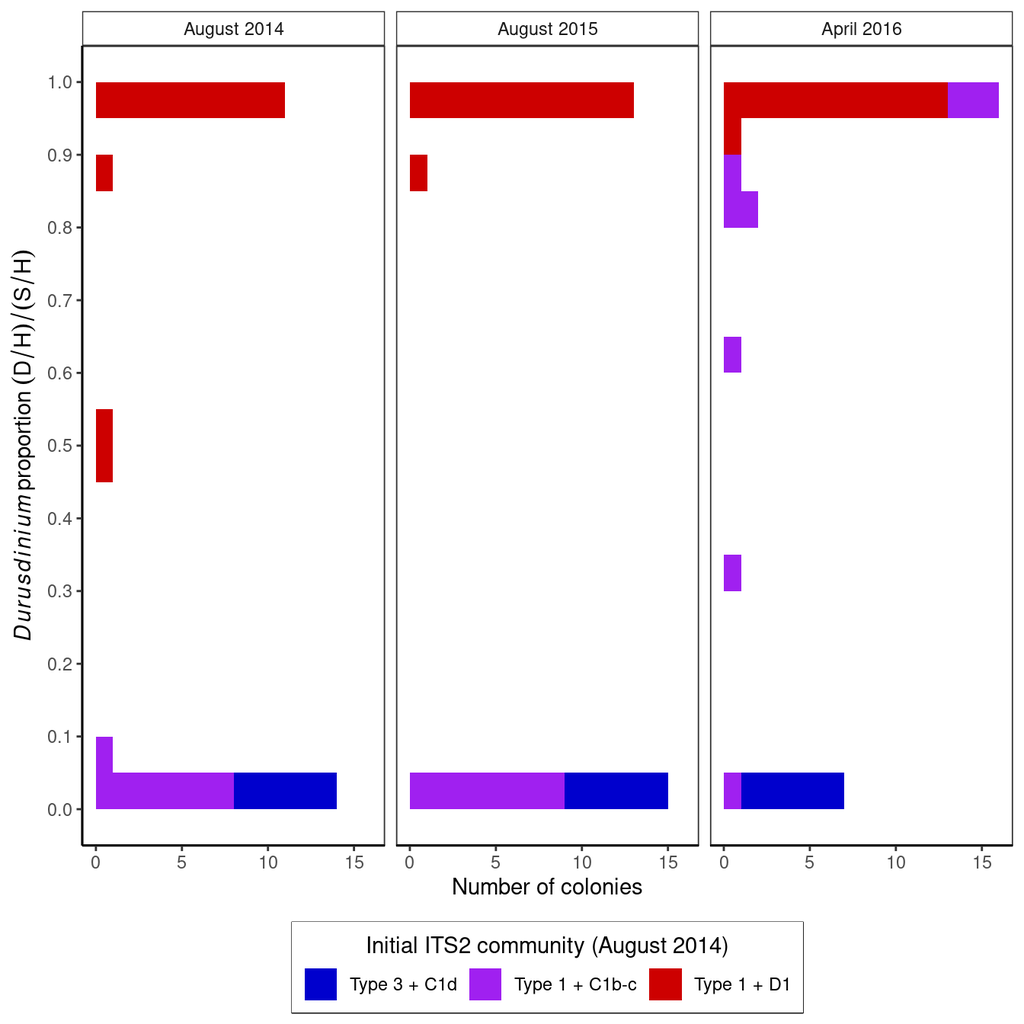

```r
data.Uva$ITS2_14<-factor(data.Uva$ITS2_14, levels = c("C1d", "C1b-c", "D1"))
data.Uva$ITS2_16<-factor(data.Uva$ITS2_16, levels = c("C1d", "C1b-c", "D1"))

Histo_Dprop_ITS2 <- ggplot(data.Uva, aes (D.Prp , fill=(ITS2_14)), shape=(D14Community))  + ggthe_bw +
      geom_histogram(binwidth = 0.05, boundary=0) +
      facet_grid(~Year.2, labeller = labeller(Year.2=c(
                    `2014` = "August 2014", `2015` = "August 2015", `2016` = "April 2016"))) +
      scale_fill_manual(values=c("blue3", "purple", "red3"),
                        guide = guide_legend(title.position = "top", nrow = 1),
                        name = "Initial ITS2 community (August 2014)",
                        labels=c("Type 3 + C1d", "Type 1 + C1b-c", "Type 1 + D1")) +
      scale_x_continuous(name= expression(
                        italic(Durusdinium)~proportion~(D/H)/(S/H)),
                        breaks=(seq(0,1,by=0.1))) +
      scale_y_continuous((name= "Number of colonies"),
                         breaks=seq(0,15,by=5)) +
      theme(legend.position="bottom",
            legend.title.align=0.5,
            strip.background =element_rect(fill=NA))
Histo_Dprop_ITS2 +coord_flip()
```

- Histograms based on ORF lineage

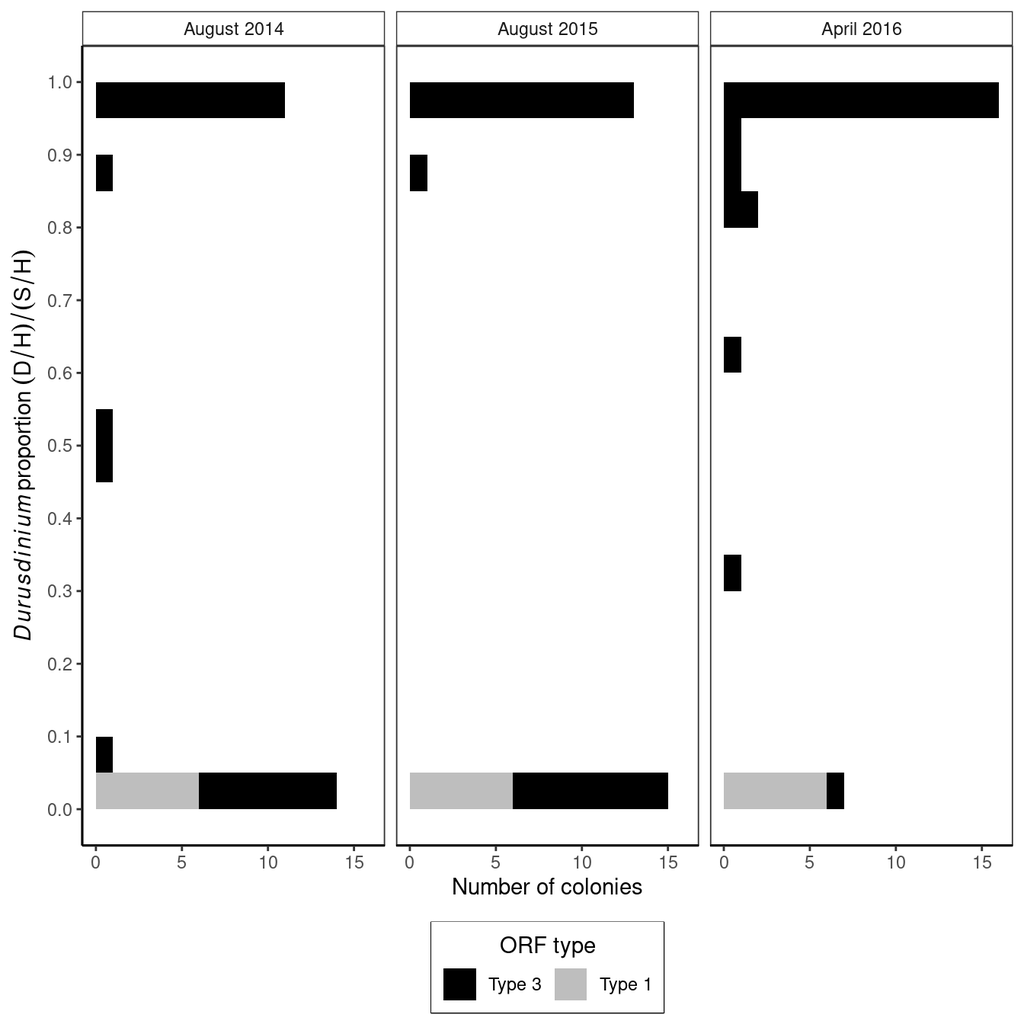

```r
Histo_Dprop_ORF <- ggplot(data.Uva, aes (D.Prp , fill=(ORF)), shape=(D14Community))  + ggthe_bw +
      geom_histogram(binwidth = 0.05, boundary=0) +
      facet_grid(~Year.2, labeller = labeller(Year.2=c(
                    `2014` = "August 2014",
                    `2015` = "August 2015", `2016` = "April 2016"))) +
      scale_fill_manual(values=c("black","gray"),
                        guide = guide_legend(title.position = "top", nrow = 1),
                        name = "ORF type",
                        labels=c("Type 3", "Type 1")) +
      scale_x_continuous(name= expression(
                        italic(Durusdinium)~proportion~(D/H)/(S/H)),
                        breaks=(seq(0,1,by=0.1))) +
      scale_y_continuous((name= "Number of colonies"),
                         breaks=seq(0,15,by=5)) +
      theme(legend.position="bottom",
            legend.title.align=0.5,
            strip.background =element_rect(fill=NA))
Histo_Dprop_ORF +coord_flip()
```

- Durusdinium proportion trajectory

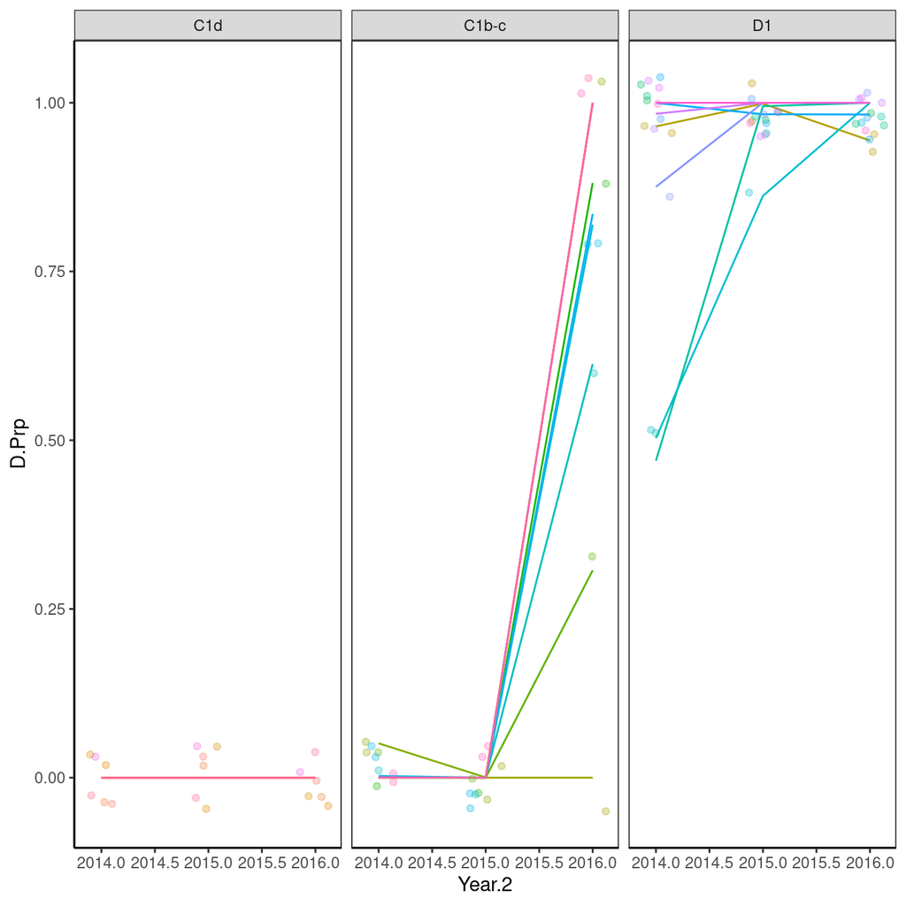

```r
# By ITS2 type
Traject_Proportion_FacetITS2 <- ggplot (data.Uva) +
   ggthe_bw +
    geom_line(aes (x=Year.2, D.Prp, colour=factor(Colony)))+
    facet_wrap(~ITS2_14) +
    geom_jitter(aes(Year.2, D.Prp, colour=factor(Colony)), alpha=0.3,
              height = 0.05, width = 0.15) +
    #labs(x = "Año del muestreo", y = "Durusdinium Proportion") +
    theme(legend.position="none")
Traject_Proportion_FacetITS2
```

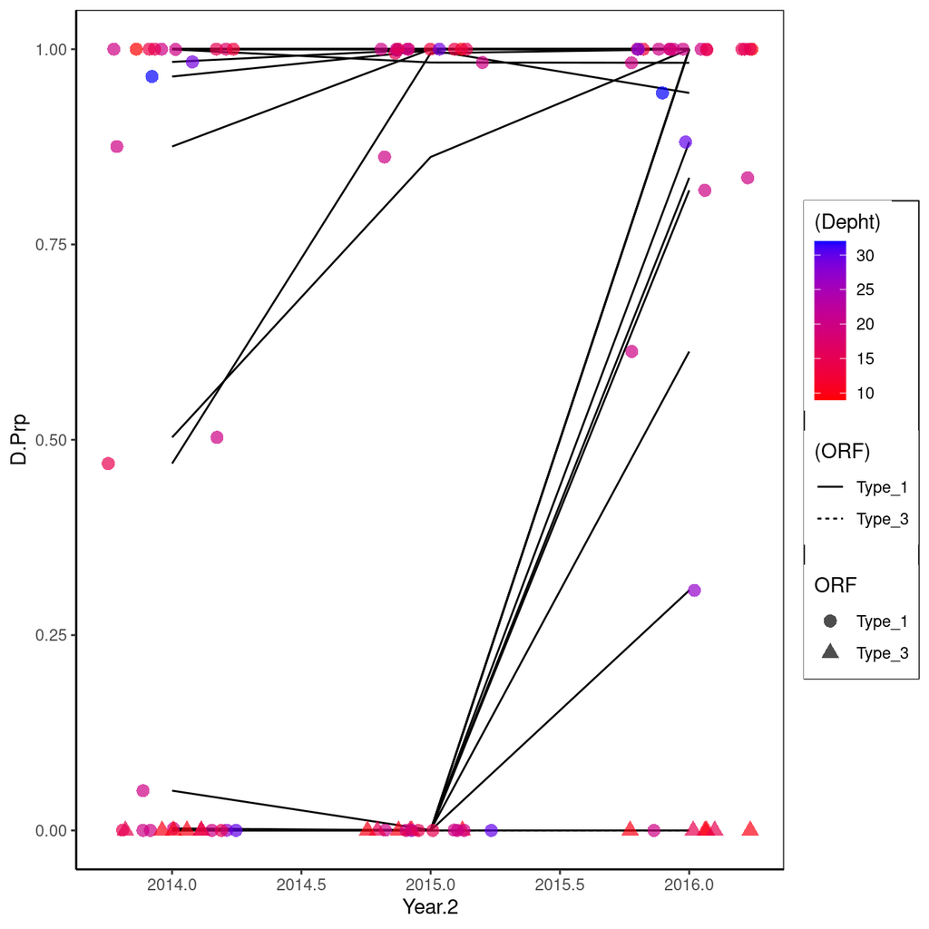

```r
# By Depth
Traject_Proportion_FacetORF <- ggplot (data.Uva) +    ggthe_bw +
      geom_line(aes (x=Year.2, D.Prp, group=Colony, linetype=(ORF)))+
      geom_jitter(aes(Year.2, D.Prp, colour=(Depht), shape=ORF),
              height = 0.00, width = 0.25, size=3, alpha=0.7) +
      scale_colour_gradient(low = "red", high = "blue")
Traject_Proportion_FacetORF
```

```r
Histo2014_DpropITS2 <- ggplot(data.Uva[which(data.Uva$Year.2==2014), ], aes (D.Prp , fill=(ITS2_14))) +
        ggthe_bw + ggtitle("a.")+
        geom_histogram(binwidth = 0.05, boundary=0) +
        scale_fill_manual(values=c("blue3","purple", "red3"),
                          guide = guide_legend(title.position = "top", nrow = 1),
                          name = "Dominant ITS2 community (August 2014)",
                          labels=c("C1d", "C1b-c", "D.glynnii")) +
        scale_x_continuous(name= expression(
                          italic(Durusdinium)~proportion),
                          breaks=(seq(0,1,by=0.1)),
                          expand=c(0.01,0.01)) +
        scale_y_continuous((name= "Number of colonies \n (Aug 2014)"),
                          limits = c(0,17),
                          breaks=seq(0,15,by=5)) +
        theme(legend.position="bottom",
              legend.title.align=0.5,
              strip.background =element_rect(fill=NA))
#Histo2014_DpropITS2

Histo2016_DpropITS2 <- ggplot(data.Uva[which(data.Uva$Year.2==2016), ], aes (D.Prp , fill=(ITS2_16))) +
        ggthe_bw + ggtitle("c.")+
        geom_histogram(binwidth = 0.05, boundary=0) +
        scale_fill_manual(values=c("blue3","purple", "red3"),
                          guide = guide_legend(title.position = "top", nrow = 1),
                          name = "Dominant ITS2 community (April 2016)",
                          labels=c("C1d", "C1b-c", "D.glynnii")) +
        scale_x_continuous(name="",
                           breaks=(seq(0,1,by=0.1)),
                           expand=c(0.01,0.01)) +
        scale_y_continuous((name= "Number of colonies \n (Aug 2016)"),
                          limits = c(0,17),
                          breaks=seq(0,15,by=5)) +
        theme(legend.position="bottom",
              legend.title.align=0.5,
              strip.background =element_rect(fill=NA))
#Histo2016_DpropITS2

Traject_ProportionITS2<- ggplot(data.Uva, aes (x=Year.2, y=D.Prp ,
                                fill=ITS2_14, shape=Mortality, group=(Colony)))+
        ggthe_bw + ggtitle("b.") +
        geom_line(aes(colour=ITS2_14), linetype=2) +
        geom_jitter(height = 0, width = 0.25, alpha=0.4) +

        scale_colour_manual(values=c("blue3","purple", "red3"),
                          guide = guide_legend(title.position = "top", nrow = 1),
                          name = "Initial ITS2 community (August 2014)",
                          labels=c("C1d", "C1b-c", "D.glynnii")) +

        scale_fill_manual(values=c("blue3","purple", "red3"),
                          guide = guide_legend(title.position = "top", nrow = 1),
                          name = "Initial ITS2 community (August 2014)",
                          labels=c("C1d", "C1b-c", "D.glynnii")) +
        scale_shape_manual(values=c(21, 22, 24),
                      labels=c("No", "Partial", "Almost total"))+

        scale_x_continuous(name="",
                           breaks = c(2014, 2015, 2016),
                           labels = c(" Aug \n 2014", " Aug \n 2015", " Apr \n 2016")) +
        scale_y_continuous((name= ""),
                           breaks=seq(0,1,by=0.1),
                           expand=c(0.01,0.01)) +

        theme(legend.position="bottom",
              legend.title.align=0.5,
              strip.background =element_rect(fill=NA))
#Traject_ProportionITS2


# Figure_2_ITS2<-grid.arrange(Histo2014_DpropITS2, Traject_ProportionITS2,Histo2016_DpropITS2,
# nrow=1, widths=c(2/9, 5/9, 2/9))

# ggsave(file="Outputs/Figure_ITS2.svg", plot=Figure_2_ITS2, width=6.5, height=5)
```

```r
Histo2014_DpropITS2b<- Histo2014_DpropITS2 + facet_grid(ORF~.)

Histo2016_DpropITS2b<- Histo2016_DpropITS2 + facet_grid(ORF~.)

Traject_ProportionITS2b<- Traject_ProportionITS2 + facet_grid(ORF~.)

# Figure_2_ITS2b<-grid.arrange(Histo2014_DpropITS2b, Traject_ProportionITS2b,Histo2016_DpropITS2b,
# nrow=1, widths=c(3/9, 3/9, 3/9))

# ggsave(file="Outputs/Figure_2_ITS2b.svg", plot=Figure_2_ITS2b, width=7, height=4)
```

```r
Histo2014_DpropORF <- ggplot(data.Uva[which(data.Uva$Year.2==2014), ], aes (D.Prp , fill=(ORFCommunity))) +
        ggthe_bw + coord_flip()+ ggtitle("a.")+
        geom_histogram(binwidth = 0.05, boundary=0, colour="black") +
        scale_fill_manual(values=c("gray", "white","snow", "mintcream"),
                       guide = guide_legend(title.position = "top", nrow = 2),
                      name = "")+
                       #labels=c("Type 3", "Type 1")) +
        scale_x_continuous(#name= expression(
                          #italic(Durusdinium)~proportion~((D/H)/(S/H))),
                          breaks=(seq(0,1,by=0.1)),
                          expand=c(0.01,0.01)) +
        scale_y_continuous((name= "Number of colonies \n (Aug 2014)"),
                          limits = c(0,16),
                          breaks=seq(0,15,by=5)) +
        theme(legend.position="bottom",
              legend.title.align=0.5,
              strip.background =element_rect(fill=NA),
              panel.border = element_blank(),
              axis.line = element_line(colour = "black"))
#Histo2014_DpropORF

Histo2016_DpropORF <- ggplot(data.Uva[which(data.Uva$Year.2==2016), ], aes (D.Prp , fill=(ORFCommunity))) +
        ggthe_bw + coord_flip()+ ggtitle("c.")+
        geom_histogram(binwidth = 0.05, boundary=0,
                       colour="black") +
        scale_fill_manual(values=c("gray", "white","snow", "mintcream"),
                       guide = guide_legend(title.position = "top", nrow = 2),
                      name = "")+
                       #labels=c("Type 3", "Type 1")) +
        scale_x_continuous(name="",
                           breaks=(seq(0,1,by=0.1)),
                           expand=c(0.01,0.01)) +
        scale_y_continuous((name= "Number of colonies \n (Aug 2016)"),
                          limits = c(0,16),
                          breaks=seq(0,15,by=5)) +
          theme(legend.position="bottom",
              legend.title.align=0.5,
              strip.background =element_rect(fill=NA),
              panel.border = element_blank(),
              axis.line = element_line(colour = "black"))
#Histo2016_DpropORF

Traject_ProportionORF_a<- ggplot(data.Uva, aes (x=Year.2, y=D.Prp))+
        ggthe_bw + ggtitle("b.") +
        geom_line(aes(colour=(ORF), group=(Colony)), linetype=2) +
        scale_colour_manual(values=c("black", "gray"),
                          guide = guide_legend(title.position = "top", nrow = 2),
                          name = "Pocillopora type",
                          labels=c("Type 3", "Type 1")) +
        scale_x_continuous(name="",
                           breaks = c(2014, 2015, 2016),
                           labels = c(" Aug \n 2014", " Aug \n 2015", " Apr \n 2016")) +
        scale_y_continuous((name= ""),
                           breaks=seq(0,1,by=0.1),
                           expand=c(0.01,0.01)) +
        theme(legend.position="bottom",
              legend.title.align=0.5,
              strip.background =element_rect(fill=NA))

  Traject_ProportionORF <- Traject_ProportionORF_a +
  geom_jitter((aes(colour=factor(ORF))),
                    height = 0, width = 0.3, color="black", size=1, shape=21) +
        scale_fill_manual(values=c("white", "gray"))

   #Traject_ProportionORF

# Figure_2_ORF<-grid.arrange(Histo2014_DpropORF, Traject_ProportionORF, Histo2016_DpropORF,
# nrow=1, widths=c(3/9, 3/9, 3/9))

# ggsave(file="Outputs/Figure_2_ORF.svg",plot=Figure_2_ORF, width=7, height=3.8, dpi=300)
```

```r
data.Uva$Mor_ITS2<-paste(data.Uva$DominantITS2, data.Uva$Mortality, sep = "_")

data.Uva$Mor_ITS2<-factor(data.Uva$Mor_ITS2, levels = c(
  "C1d-dominated_No", "C1d-dominated_Partial", "C1d-dominated_Almost total",
  "C1bc-dominated_No", "C1bc-dominated_Partial",
  "D1-dominated_No", "D1-dominated_Partial", "D1-dominated_Almost total"))

summary(data.Uva$Mor_ITS2)
```

```
##           C1d-dominated_No      C1d-dominated_Partial
##                         11                          3
## C1d-dominated_Almost total          C1bc-dominated_No
##                          4                         17
##     C1bc-dominated_Partial            D1-dominated_No
##                          3                         43
##       D1-dominated_Partial  D1-dominated_Almost total
##                          3                          3
```

```r
Histo2014_DpropITS2 <- ggplot(data.Uva[which(data.Uva$Year.2==2014), ], aes (D.Prp , fill=(Mor_ITS2))) +
        ggthe_bw + coord_flip()+ ggtitle("a.")+
        geom_histogram(binwidth = 0.05, boundary=0) +
        scale_fill_manual(values=c("skyblue1",
                          "darkorchid1",
                          "red1"),
                          guide = guide_legend(title.position = "top", nrow = 3),
                          name = "Dominant ITS2 community (August 2014)") +

        scale_x_continuous(name= expression(
                          italic(Durusdinium)~proportion~((D/H)/(S/H))),
                          breaks=(seq(0,1,by=0.1)),
                          expand=c(0.01,0.01)) +
        scale_y_continuous((name= "Number of colonies \n (Aug 2014)"),
                          limits = c(0,17),
                          breaks=seq(0,15,by=5)) +
        theme(legend.position="bottom",
              legend.title.align=0.5,
              strip.background =element_rect(fill=NA))
#Histo2014_DpropITS2

Histo2016_DpropITS2 <- ggplot(data.Uva[which(data.Uva$Year.2==2016), ], aes (D.Prp , fill=(Mor_ITS2))) +
        ggthe_bw + coord_flip()+ ggtitle("c.")+
        geom_histogram(binwidth = 0.05, boundary=0) +
       scale_fill_manual(values=c("skyblue1", "blue2", "blue4",
                          "darkorchid3",
                          "red1", "red3", "red4"),
                          guide = guide_legend(title.position = "top", nrow = 3),
                          name = "Dominant ITS2 community (April 2016)") +
        scale_x_continuous(name="",
                           breaks=(seq(0,1,by=0.1)),
                           expand=c(0.01,0.01)) +
        scale_y_continuous((name= "Number of colonies \n (Aug 2016)"),
                          limits = c(0,17),
                          breaks=seq(0,15,by=5)) +
        theme(legend.position="bottom",
              legend.title.align=0.5,
              strip.background =element_rect(fill=NA))
#Histo2016_DpropITS2


HistoAll_DpropITS2 <- ggplot(data.Uva, aes (D.Prp , fill=(Mor_ITS2))) +
        ggthe_bw + coord_flip()+ ggtitle("c.")+
        geom_histogram(binwidth = 0.05, boundary=0) +
       scale_fill_manual(values=c("skyblue1", "blue2", "blue4",
                          "darkorchid1","darkorchid3",
                          "red1", "red3", "red4"),
                          guide = guide_legend(title.position = "top", nrow = 3),
                          name = "Dominant ITS2 community (April 2016)") +
        scale_x_continuous(name="",
                           breaks=(seq(0,1,by=0.1)),
                           expand=c(0.01,0.01)) +
        scale_y_continuous((name= "Number of colonies \n (Aug 2016)"),
                          limits = c(0,17),
                          breaks=seq(0,15,by=5)) +
        theme(legend.position="bottom",
              legend.title.align=0.5,
              strip.background =element_rect(fill=NA)) + facet_grid(ORF~Year)
#HistoAll_DpropITS2


Traject_ProportionITS2<- ggplot(data.Uva, aes (x=Year.2, y=D.Prp, group=(Colony)))+
        ggthe_bw + ggtitle("b.") +
        geom_line(aes(colour=ITS2_14),linetype=2) +
        geom_jitter(aes(colour=Mor_ITS2, shape=Mortality),
                    height = 0.00, width = 0.25, alpha=0.9) +

        scale_colour_manual(values=c(
                          "darkorchid1", "darkorchid1","darkorchid3",
                          "skyblue1","blue4", "skyblue1", "blue2",
                          "red1", "red4", "red1", "red3" ),
                          guide = guide_legend(title.position = "top", nrow = 3),
                          name = "Dominant ITS2 community (April 2016)") +

        scale_x_continuous(name="",
                           breaks = c(2014, 2015, 2016),
                           labels = c(" Aug \n 2014", " Aug \n 2015", " Apr \n 2016")) +
        scale_y_continuous((name= ""),
                           breaks=seq(0,1,by=0.1),
                           expand=c(0.01,0.01)) +

        theme(legend.position="bottom",
              legend.title.align=0.5,
              strip.background =element_rect(fill=NA))
#Traject_ProportionITS2


# Figure_2_ITS2<-grid.arrange(Histo2014_DpropITS2, Traject_ProportionITS2,Histo2016_DpropITS2,
# nrow=1, widths=c(3/9, 3/9, 3/9))

# ggsave(file="Outputs/Figure_ITS2_Mortality.svg", plot=Figure_2_ITS2, width=7, height=4)
```

### Figure 3b and 3c: ITS2 + Mortality

```r
data.Uva$Mor_ITS2<-paste(data.Uva$DominantITS2, data.Uva$Mortality, sep = "_")

data.Uva$Mor_ITS2<-factor(data.Uva$Mor_ITS2, levels = c(
   "C1d-dominated_Almost total", "C1d-dominated_Partial","C1d-dominated_No",
  "C1bc-dominated_Partial","C1bc-dominated_No",
  "D1-dominated_Almost total", "D1-dominated_Partial", "D1-dominated_No" ))

summary(data.Uva$Mor_ITS2)
```

```
## C1d-dominated_Almost total      C1d-dominated_Partial
##                          4                          3
##           C1d-dominated_No     C1bc-dominated_Partial
##                         11                          3
##          C1bc-dominated_No  D1-dominated_Almost total
##                         17                          3
##       D1-dominated_Partial            D1-dominated_No
##                          3                         43
```

```r
Histo2014_DpropITS2 <- ggplot(data.Uva[which(data.Uva$Year.2==2014), ], aes (D.Prp , fill=(Mor_ITS2))) +
        ggthe_bw + ggtitle("a.")+
        geom_histogram(binwidth = 0.05, boundary=0) +
        scale_fill_manual(values=c("black",
                          "black",
                          "black"),
                          guide = guide_legend(title.position = "top", nrow = 3),
                          name = "Dominant ITS2 community (August 2014)") +

        scale_x_continuous(name= expression(
                          italic(Durusdinium)~proportion~((D/H)/(S/H))),
                          breaks=(seq(0,1,by=0.1)),
                          expand=c(0.01,0.01)) +
        scale_y_continuous((name= "Number of colonies \n (Aug 2014)"),
                          limits = c(0,17),
                          breaks=seq(0,15,by=5)) +
        theme(legend.position="none",
              legend.title.align=0.5,
              strip.background =element_rect(fill=NA)) + facet_grid(ORF~.)
#Histo2014_DpropITS2

Histo2016_DpropITS2 <- ggplot(data.Uva[which(data.Uva$Year.2==2016), ], aes (D.Prp , fill=(Mor_ITS2))) +
        ggthe_bw + ggtitle("c.")+
        geom_histogram(binwidth = 0.05, boundary=0) +
       scale_fill_manual(values=c("white", "gray", "black",
                          "gray",
                          "white", "gray", "black"),
                          guide = guide_legend(title.position = "top", nrow = 3),
                          name = "Dominant ITS2 community (April 2016)") +
        scale_x_continuous(name="",
                           breaks=(seq(0,1,by=0.1)),
                           expand=c(0.01,0.01)) +
        scale_y_continuous((name= "Number of colonies \n (Aug 2016)"),
                          limits = c(0,17),
                          breaks=seq(0,15,by=5)) +
        theme(legend.position="none",
              legend.title.align=0.5,
              strip.background =element_rect(fill=NA)) +  facet_grid(ORF~.)
#Histo2016_DpropITS2


HistoAll_DpropITS2 <- ggplot(data.Uva, aes (D.Prp , fill=(Mor_ITS2))) +
        ggthe_bw + ggtitle("c.")+
        geom_histogram(binwidth = 0.05, boundary=0) +
       scale_fill_manual(values=c("skyblue1", "blue2", "blue4",
                          "darkorchid1","darkorchid3",
                          "red1", "red3", "red4"),
                          guide = guide_legend(title.position = "top", nrow = 3),
                          name = "Dominant ITS2 community (April 2016)") +
        scale_x_continuous(name="",
                           breaks=(seq(0,1,by=0.1)),
                           expand=c(0.01,0.01)) +
        scale_y_continuous((name= "Number of colonies \n (Aug 2016)"),
                          limits = c(0,17),
                          breaks=seq(0,15,by=5)) +
        theme(legend.position="bottom",
              legend.title.align=0.5,
              strip.background =element_rect(fill=NA)) + facet_grid(ORF~Year)
#HistoAll_DpropITS2

HistoAll_DpropITS2 <- ggplot(data.Uva, aes (D.Prp , fill=(Mor_ITS2))) +
        ggthe_bw + ggtitle("c.")+
        geom_histogram(binwidth = 0.05, boundary=0, color = "black") +
       scale_fill_manual(values=c("white", "gray", "black",
                          "gray","black",
                          "white", "gray", "black"),
                          guide = guide_legend(title.position = "top", nrow = 3),
                          name = "Dominant ITS2 community (April 2016)") +
        scale_x_continuous(name="",
                           breaks=(seq(0,1,by=0.1)),
                           expand=c(0.01,0.01)) +
        scale_y_continuous((name= "Number of colonies"),
                          limits = c(0,14),
                          breaks=seq(0,14,by=2)) +
        theme(legend.position="bottom",
              legend.title.align=0.5,
              strip.background =element_rect(fill=NA)) +
        facet_grid(ORF~Year) + theme(legend.position = "none")
#HistoAll_DpropITS2
#ggsave(file="Outputs/Panels.svg", plot=HistoAll_DpropITS2, width=6, height=2.8)



Traject_ProportionITS2<- ggplot(data.Uva, aes (x=Year.2, y=D.Prp, group=(Colony)))+
        ggthe_bw + ggtitle("b.") +
        geom_line(linetype=2) +
        geom_jitter(aes(colour=Mortality, shape=ORF), size=1.5,
                    height = 0.00, width = 0.25, alpha=1) +

        scale_colour_manual(values=c("black", "gray","white")) +

        scale_x_continuous(name="",
                           breaks = c(2014, 2015, 2016),
                           labels = c(" Aug \n 2014", " Aug \n 2015", " Apr \n 2016")) +
        scale_y_continuous((name= ""),
                           breaks=seq(0,1,by=0.1),
                           expand=c(0.02,0.02)) +

        theme(legend.position="none",
              legend.title.align=0.5,
              strip.background =element_rect(fill=NA))# + facet_grid(ORF~.)
#Traject_ProportionITS2
#ggsave(file="Outputs/Trajectory.svg", plot=Traject_ProportionITS2, width=6.5, height=3)

# Figure_2_ITS2<-grid.arrange(Histo2014_DpropITS2, Traject_ProportionITS2,Histo2016_DpropITS2,
# nrow=1, widths=c(2.5/9, 4/9, 2.5/9))

# ggsave(file="Outputs/Figure_ITS2_Mortality2.svg", plot=Figure_2_ITS2, width=7, height=4)
```

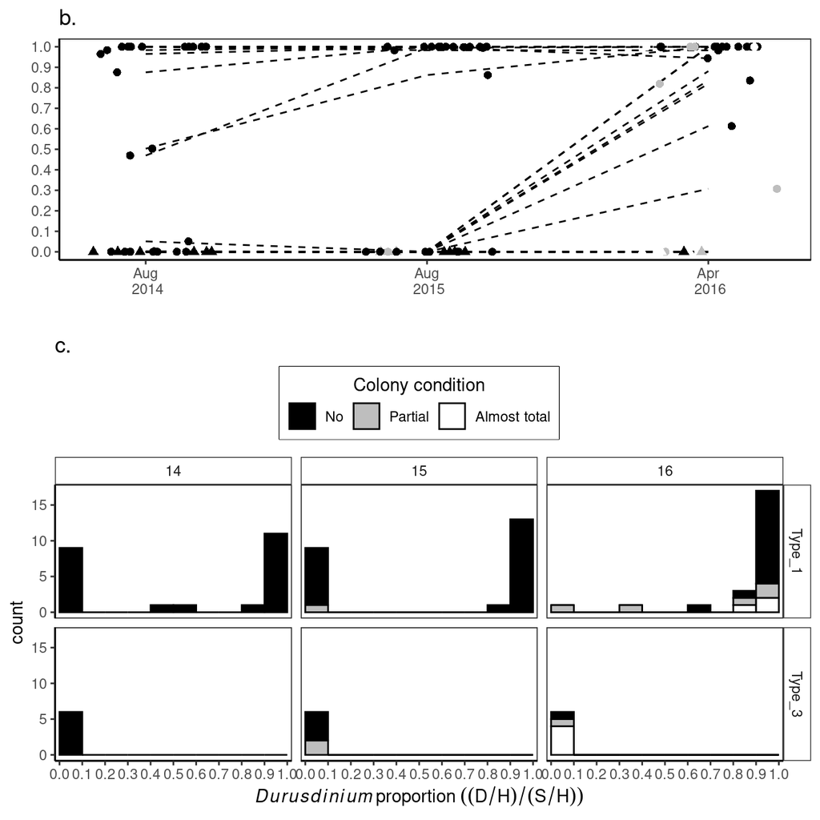

```r
DpropORF <- ggplot(data.Uva, aes (D.Prp , fill=(Mortality))) +
        ggthe_bw + ggtitle("c.")+
        geom_histogram(binwidth = 0.1, boundary=0, color="black") +
        scale_fill_manual(values=c("black",
                          "gray",
                          "white"),
                          guide = guide_legend(title.position = "top", nrow = 1),
                          name = "Colony condition") +

        scale_x_continuous(name= expression(
                          italic(Durusdinium)~proportion~((D/H)/(S/H))),
                          breaks=(seq(0,1,by=0.1)),
                          expand=c(0.01,0.01)) +
        scale_y_continuous(limits = c(0,17),
                          breaks=seq(0,15,by=5)) +
        theme(legend.position="top",
              legend.title.align=0.5,
              strip.background =element_rect(fill=NA)) + facet_grid(ORF~Year)
#DpropORF

Traject_ORF<- ggplot(data.Uva, aes (x=Year.2, y=D.Prp, group=(Colony)))+
        ggthe_bw + ggtitle("b.") +
        geom_line(linetype=2) +
        geom_jitter(aes(colour=Mortality, shape=ORF), size=2,
                    height = 0.00, width = 0.25, alpha=1) +

        scale_colour_manual(values=c("black", "gray","white")) +

        scale_x_continuous(name="",
                           breaks = c(2014, 2015, 2016),
                           labels = c(" Aug \n 2014", " Aug \n 2015", " Apr \n 2016")) +
        scale_y_continuous((name= ""),
                           breaks=seq(0,1,by=0.1),
                           expand=c(0.02,0.02)) +

        theme(legend.position="none",
              legend.title.align=0.5,
              strip.background =element_rect(fill=NA))# + facet_grid(ORF~.)
#Traject_ORF

Figure_3bc_ORF<-grid.arrange(Traject_ORF, DpropORF,
nrow=2, heights=c(1.2/3, 1.8/3))
```

```r
#ggsave(file="Outputs/Fig3_v8.svg", plot=Figure_3bc_ORF, width=6.5, height=7)
```

```r
# Summary dominant genera
  Community_prescence_absence<-data.Uva %>%
        group_by(ORF, Community, Year.2) %>%
        dplyr::summarise(total.count=n())
  Community_prescence_absence
```

| ORF | Community | Year.2 | total.count |
| --- | --- | --- | --- |
| Type_1 | Cladocopium-only | 2014 | 3 |
| Type_1 | Cladocopium-only | 2015 | 7 |
| Type_1 | Cladocopium-only | 2016 | 1 |
| Type_1 | Mixed | 2014 | 12 |
| Type_1 | Mixed | 2015 | 6 |
| Type_1 | Mixed | 2016 | 8 |
| Type_1 | Durusdinium-only | 2014 | 8 |
| Type_1 | Durusdinium-only | 2015 | 10 |
| Type_1 | Durusdinium-only | 2016 | 14 |
| Type_3 | Cladocopium-only | 2014 | 6 |

[output cut: 2 more lines]

```r
  Community_dominance<-data.Uva %>%
        group_by(ORF, DominantCommunity, Year.2) %>%
        dplyr::summarise(total.count=n())
  Community_dominance
```

| ORF | DominantCommunity | Year.2 | total.count |
| --- | --- | --- | --- |
| Type_1 | Cladocopium-dominated | 2014 | 9 |
| Type_1 | Cladocopium-dominated | 2015 | 9 |
| Type_1 | Cladocopium-dominated | 2016 | 2 |
| Type_1 | Durusdinium-dominated | 2014 | 14 |
| Type_1 | Durusdinium-dominated | 2015 | 14 |
| Type_1 | Durusdinium-dominated | 2016 | 21 |
| Type_3 | Cladocopium-dominated | 2014 | 6 |
| Type_3 | Cladocopium-dominated | 2015 | 6 |
| Type_3 | Cladocopium-dominated | 2016 | 6 |

```r
  Community_dominance<-data.Uva %>%
        group_by(ORF, Year.2, DominantCommunity,
                Community) %>%
        dplyr::summarise(total.count=n())
  Community_dominance
```

| ORF | Year.2 | DominantCommunity | Community | total.count |
| --- | --- | --- | --- | --- |
| Type_1 | 2014 | Cladocopium-dominated | Cladocopium-only | 3 |
| Type_1 | 2014 | Cladocopium-dominated | Mixed | 6 |
| Type_1 | 2014 | Durusdinium-dominated | Mixed | 6 |
| Type_1 | 2014 | Durusdinium-dominated | Durusdinium-only | 8 |
| Type_1 | 2015 | Cladocopium-dominated | Cladocopium-only | 7 |
| Type_1 | 2015 | Cladocopium-dominated | Mixed | 2 |
| Type_1 | 2015 | Durusdinium-dominated | Mixed | 4 |
| Type_1 | 2015 | Durusdinium-dominated | Durusdinium-only | 10 |
| Type_1 | 2016 | Cladocopium-dominated | Cladocopium-only | 1 |
| Type_1 | 2016 | Cladocopium-dominated | Mixed | 1 |

[output cut: 5 more lines]

```r
  # SH_mean<-data.Uva %>%
  #       group_by(ORF, Year.2, DominantCommunity) %>%
  #       dplyr::summarise(mean=mean(tot.SH))
  # SH_mean
  #
  # SH_SE<-data.Uva %>%
  #       group_by(ORF, Year.2, DominantCommunity) %>%
  #       dplyr::summarise(sd=sd(tot.SH))
  # SH_SE
```

## 7b. Changes in total Symbiodiniaceae abundance (bleaching): qPCR + ORF

### Figure 3: ORF + Dominant symbiont

```r
#SH_2014CoI<-lm(logTot.SH ~ Year * ORF * DominantCommunity,             data=data.Uva)
SH_2014CoI<-lmerTest::lmer(logTot.SH ~ Year * ORF * DominantCommunity + (1|Colony), data=data.Uva)

    summary(SH_2014CoI)
```

```
## Linear mixed model fit by REML. t-tests use Satterthwaite's method [
## lmerModLmerTest]
## Formula: logTot.SH ~ Year * ORF * DominantCommunity + (1 | Colony)
##    Data: data.Uva
##
## REML criterion at convergence: 75.9
##
## Scaled residuals:
##     Min      1Q  Median      3Q     Max
## -2.3367 -0.5185 -0.0403  0.3713  3.4413
##
## Random effects:
##  Groups   Name        Variance Std.Dev.
##  Colony   (Intercept) 0.01992  0.1411
##  Residual             0.10475  0.3236
## Number of obs: 87, groups:  Colony, 29
##
## Fixed effects:
##                                               Estimate Std. Error       df
## (Intercept)                                   -1.68521    0.11691 77.39879
## Year15                                         0.22667    0.15257 51.72506
## Year16                                        -0.05117    0.26368 68.09623
## ORFType_3                                      0.02507    0.18560 75.84196
## DominantCommunityDurusdinium-dominated         0.14102    0.14919 77.99999
## Year15:ORFType_3                              -0.79408    0.24123 51.72506
## Year16:ORFType_3                              -0.72686    0.32318 62.79186
## Year15:DominantCommunityDurusdinium-dominated -0.06059    0.19555 51.72506
## Year16:DominantCommunityDurusdinium-dominated  0.01196    0.28860 68.27239
##                                               t value Pr(>|t|)
## (Intercept)                                   -14.415   <2e-16 ***
## Year15                                          1.486   0.1434
## Year16                                         -0.194   0.8467
## ORFType_3                                       0.135   0.8929
## DominantCommunityDurusdinium-dominated          0.945   0.3475
## Year15:ORFType_3                               -3.292   0.0018 **
## Year16:ORFType_3                               -2.249   0.0280 *
## Year15:DominantCommunityDurusdinium-dominated  -0.310   0.7579
## Year16:DominantCommunityDurusdinium-dominated   0.041   0.9671
## ---
## Signif. codes:  0 '***' 0.001 '**' 0.01 '*' 0.05 '.' 0.1 ' ' 1
##
## Correlation of Fixed Effects:
##             (Intr) Year15 Year16 ORFT_3 DmnCD- Y15:OR Y16:OR Y15:DC
## Year15      -0.653
## Year16      -0.373  0.289
## ORFType_3   -0.630  0.411  0.235
## DmnntCmmnD- -0.777  0.511  0.290  0.489
## Yr15:ORFT_3  0.413 -0.632 -0.183 -0.650 -0.323
## Yr16:ORFT_3  0.305 -0.236 -0.816 -0.483 -0.237  0.373
## Yr15:DmnCD-  0.509 -0.780 -0.226 -0.321 -0.655  0.493  0.184
## Yr16:DmnCD-  0.359 -0.264 -0.920 -0.226 -0.463  0.167  0.750  0.339
## fit warnings:
## fixed-effect model matrix is rank deficient so dropping 3 columns / coefficients
```

```r
    anova(SH_2014CoI)
```

|  | Sum Sq | Mean Sq | NumDF | DenDF | F value | Pr(>F) |
| --- | --- | --- | --- | --- | --- | --- |
| Year | 1.16347435 | 0.581737175 | 2 | 54.67619 | 5.55364533 | 0.006371510 |
| ORF | 1.19974496 | 1.199744959 | 1 | 40.94222 | 11.45355372 | 0.001583409 |
| DominantCommunity | 0.11672712 | 0.116727119 | 1 | 62.50175 | 1.11435378 | 0.295200941 |
| Year:ORF | 1.26176734 | 0.630883669 | 2 | 58.09447 | 6.02283005 | 0.004197718 |
| Year:DominantCommunity | 0.01259174 | 0.006295868 | 2 | 60.88957 | 0.06010449 | 0.941721930 |
| ORF:DominantCommunity | NA | NA | NA | NA | NA | NA |
| Year:ORF:DominantCommunity | NA | NA | NA | NA | NA | NA |

```r
    ranova(SH_2014CoI)
```

|  | npar | logLik | AIC | LRT | Df | Pr(>Chisq) |
| --- | --- | --- | --- | --- | --- | --- |
|  | 11 | -37.96643 | 97.93286 | NA | NA | NA |
| (1 \| Colony) | 10 | -38.88420 | 97.76840 | 1.835542 | 1 | 0.1754743 |

```r
    step(SH_2014CoI, reduce.random=FALSE)
```

```
## Backward reduced random-effect table:
##
##              Eliminated npar  logLik    AIC    LRT Df Pr(>Chisq)
## <none>                    11 -37.966 97.933
## (1 | Colony)          0   10 -38.884 97.768 1.8355  1     0.1755
##
## Backward reduced fixed-effect table:
## Degrees of freedom method: Satterthwaite
##
##                            Eliminated Sum Sq Mean Sq NumDF DenDF F value Pr(>F)
## Year:ORF:DominantCommunity          0
##
## Model found:
## logTot.SH ~ Year * ORF * DominantCommunity + (1 | Colony)
```

```r
    SH_2014CoI<-lm(logTot.SH ~ Year * ORF * DominantCommunity, data=data.Uva)

    SH_I.emmc<-emmeans(SH_2014CoI, ~Year*ORF*DominantCommunity)
    SH_I_groups<-multcomp::cld(SH_I.emmc)
    SH_I_groups<-as.data.frame(SH_I_groups[complete.cases(SH_I_groups),])
    SH_I_groups<-SH_I_groups[order(
      SH_I_groups$Year, SH_I_groups$ORF),]
    SH_I_groups
```

|  | Year | ORF | DominantCommunity | emmean | SE | df | lower.CL | upper.CL | .group |
| --- | --- | --- | --- | --- | --- | --- | --- | --- | --- |
| 1 | 14 | Type_1 | Cladocopium-dominated | -1.677600 | 0.11771894 | 78 | -1.911960 | -1.443239 | 23 |
| 7 | 14 | Type_1 | Durusdinium-dominated | -1.549079 | 0.09438513 | 78 | -1.736985 | -1.361173 | 3 |
| 4 | 14 | Type_3 | Cladocopium-dominated | -1.660140 | 0.14417567 | 78 | -1.947171 | -1.373108 | 23 |
| 2 | 15 | Type_1 | Cladocopium-dominated | -1.450925 | 0.11771894 | 78 | -1.685286 | -1.216565 | 3 |
| 8 | 15 | Type_1 | Durusdinium-dominated | -1.382992 | 0.09438513 | 78 | -1.570899 | -1.195086 | 3 |
| 5 | 15 | Type_3 | Cladocopium-dominated | -2.227545 | 0.14417567 | 78 | -2.514577 | -1.940513 | 12 |
| 3 | 16 | Type_1 | Cladocopium-dominated | -1.690394 | 0.24971958 | 78 | -2.187547 | -1.193240 | 123 |
| 9 | 16 | Type_1 | Durusdinium-dominated | -1.587779 | 0.07706514 | 78 | -1.741204 | -1.434355 | 3 |
| 6 | 16 | Type_3 | Cladocopium-dominated | -2.438176 | 0.14417567 | 78 | -2.725207 | -2.151144 | 1 |

```r
    #write.csv(SH_I_groups,"Outputs/SH_ORF_Dominant_groups2.csv")

# plot(emmeans(SH_2014CoI, ~Year|~DominantCommunity), comparisons = TRUE) + coord_flip(xlim = NULL, ylim = NULL, expand = TRUE) + facet_wrap(~DominantITS2)+ ggthe_bw
```

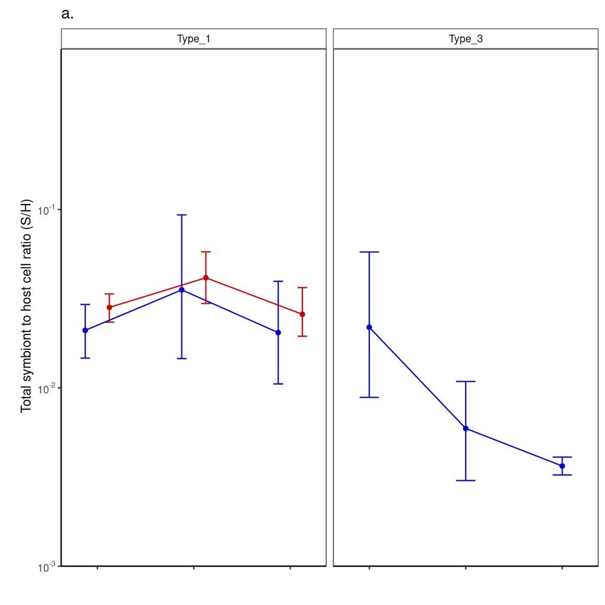

```r
SH_2014ComI <- ggplot(data.Uva, aes (Year.2, logTot.SH, colour=factor(DominantITS2))) +  ggthe_bw + facet_wrap(~ORF) + ggtitle("a.")+
  #geom_point(alpha=0.5)+
  #geom_line(aes(group=(Colony)))+
  stat_summary(fun.data = "mean_cl_boot",geom = "errorbar", width = 0.2,
                   position=position_dodge(width=0.5))+
  stat_summary(fun.data = "mean_cl_boot",geom = "point",
                   position=position_dodge(width=0.5))+
  stat_summary(fun.y=mean, geom="line", position=position_dodge(width=0.5)) +
   scale_colour_manual(values=c("blue3","blue3" , "red3"),
                        guide = guide_legend(title.position = "top", nrow = 3),
                        name = "Dominant symbiont",
                        labels=c("Cladocopium", "Durusdinium"))+
      theme(legend.position="mone",
            strip.background =element_rect(fill="white"))+

      scale_y_continuous(limits = c(-3, -0.1),
            name="\n Total symbiont to host cell ratio (S/H)",
            labels = (math_format(10^.x)),
            expand = c(0.0, 0)) +
      scale_x_continuous(name="",
                         breaks = c(2014, 2015, 2016),
                         labels = c(" ", "", " "))
SH_2014ComI
```

```r
#ggsave(file="Figure_3.svg", plot=SH_ITS2_Comunities, width=6, height=4, dpi=300)
```

## 8b. Changes in *Cladocopium* abundance

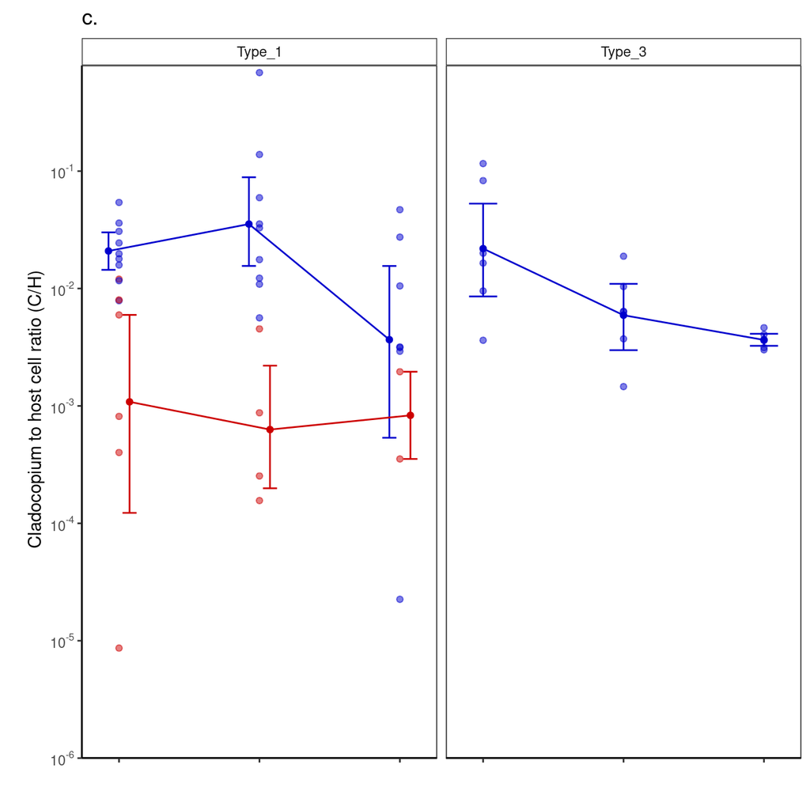

```r
CH_Com2ITS2 <- ggplot(data.Uva, aes (Year.2, logC.SH, colour=factor(D14Dominant))) + ggthe_bw+ ggtitle("c.") + facet_grid(~ORF) +
  geom_point(alpha=0.5)+

      stat_summary(fun.data = "mean_cl_boot",geom = "errorbar", width = 0.2, position=position_dodge(width=0.3))+
      stat_summary(fun.data = "mean_cl_boot",geom = "point", position=position_dodge(width=0.3))+
      stat_summary(fun.y=mean, geom="line", position=position_dodge(width=0.3)) +

      scale_colour_manual(values=c("blue3", "red3"),
                         guide = guide_legend(title.position = "top", nrow = 3),
                         name = "Dominant symbiont",
                         labels=c("Cladocopium", "Durusdinium"))+
     theme(legend.position="mone",
            strip.background =element_rect(fill="white"))+

      scale_y_continuous(limits = c(-6, -0.1),
            name="\n Cladocopium to host cell ratio (C/H)",
            labels = (math_format(10^.x)),
            expand = c(0.0, 0)) +
      scale_x_continuous(name="",
                         breaks = c(2014, 2015, 2016),
                         labels = c(" ", " ", " "))
CH_Com2ITS2
```

```r
CH_I<-lmerTest::lmer(logC.SH ~ Year* DominantITS2 + (1|Colony), data=data.Uva)
    summary(CH_I)
```

```
## Linear mixed model fit by REML. t-tests use Satterthwaite's method [
## lmerModLmerTest]
## Formula: logC.SH ~ Year * DominantITS2 + (1 | Colony)
##    Data: data.Uva
##
## REML criterion at convergence: 108.7
##
## Scaled residuals:
##      Min       1Q   Median       3Q      Max
## -2.89915 -0.40700 -0.07625  0.38592  1.92091
##
## Random effects:
##  Groups   Name        Variance Std.Dev.
##  Colony   (Intercept) 0.06891  0.2625
##  Residual             0.38254  0.6185
## Number of obs: 55, groups:  Colony, 21
##
## Fixed effects:
##                                  Estimate Std. Error       df t value Pr(>|t|)
## (Intercept)                      -1.68510    0.22354 44.93743  -7.538 1.65e-09
## Year15                            0.22932    0.29156 28.78344   0.787 0.437988
## Year16                           -0.12883    0.50336 39.26788  -0.256 0.799334
## DominantITS2C1d-dominated         0.02496    0.35386 44.57426   0.071 0.944077
## DominantITS2D1-dominated         -1.27282    0.35244 45.62565  -3.611 0.000755
## Year15:DominantITS2C1d-dominated -0.79673    0.46100 28.78344  -1.728 0.094658
## Year16:DominantITS2C1d-dominated -0.64921    0.61716 35.78277  -1.052 0.299886
## Year15:DominantITS2D1-dominated  -0.44588    0.49919 31.70568  -0.893 0.378478
## Year16:DominantITS2D1-dominated   0.31093    0.62644 42.90497   0.496 0.622184
##
## (Intercept)                      ***
## Year15
## Year16
## DominantITS2C1d-dominated
## DominantITS2D1-dominated         ***
## Year15:DominantITS2C1d-dominated .
## Year16:DominantITS2C1d-dominated
## Year15:DominantITS2D1-dominated
## Year16:DominantITS2D1-dominated
## ---
## Signif. codes:  0 '***' 0.001 '**' 0.01 '*' 0.05 '.' 0.1 ' ' 1
##
## Correlation of Fixed Effects:
##             (Intr) Year15 Year16 DITS2C DITS2D Y15:DITS2C Y16:DITS2C Y15:DITS2D
## Year15      -0.652
## Year16      -0.376  0.290
## DmnnITS2C1- -0.632  0.412  0.238
## DmnnITS2D1- -0.631  0.414  0.238  0.398
## Y15:DITS2C1  0.412 -0.632 -0.183 -0.651 -0.262
## Y16:DITS2C1  0.307 -0.236 -0.816 -0.486 -0.194  0.373
## Y15:DITS2D1  0.382 -0.584 -0.170 -0.241 -0.606  0.369      0.138
## Y16:DITS2D1  0.339 -0.233 -0.816 -0.214 -0.538  0.147      0.665      0.345
```

```r
    anova (CH_I)
```

|  | Sum Sq | Mean Sq | NumDF | DenDF | F value | Pr(>F) |
| --- | --- | --- | --- | --- | --- | --- |
| Year | 0.5123584 | 0.2561792 | 2 | 34.17437 | 0.6696791 | 0.5184616322 |
| DominantITS2 | 10.1960372 | 5.0980186 | 2 | 25.91886 | 13.3267535 | 0.0001046211 |
| Year:DominantITS2 | 2.3251899 | 0.5812975 | 4 | 35.12105 | 1.5195724 | 0.2176924297 |

```r
    #step(CH_I)

    CH_I.emmc<-emmeans(CH_I, ~Year*DominantITS2)
    CH_I_groups<-cld(CH_I.emmc)
    CH_I_groups<-as.data.frame(CH_I_groups[complete.cases(CH_I_groups),])
    CH_I_groups<-CH_I_groups[order(CH_I_groups$DominantITS2,CH_I_groups$Year),]
    CH_I_groups
```

|  | Year | DominantITS2 | emmean | SE | df | lower.CL | upper.CL | .group |
| --- | --- | --- | --- | --- | --- | --- | --- | --- |
| 1 | 14 | C1bc-dominated | -1.685102 | 0.2247573 | 44.90539 | -2.137813 | -1.2323912 | 3 |
| 2 | 15 | C1bc-dominated | -1.455780 | 0.2247573 | 44.90539 | -1.908491 | -1.0030695 | 3 |
| 3 | 16 | C1bc-dominated | -1.813932 | 0.4823356 | 45.18986 | -2.785293 | -0.8425706 | 123 |
| 4 | 14 | C1d-dominated | -1.660140 | 0.2743029 | 44.25628 | -2.212870 | -1.1074089 | 23 |
| 5 | 15 | C1d-dominated | -2.227545 | 0.2743029 | 44.25628 | -2.780276 | -1.6748144 | 123 |
| 6 | 16 | C1d-dominated | -2.438176 | 0.2743029 | 44.25628 | -2.990906 | -1.8854448 | 123 |
| 7 | 14 | D1-dominated | -2.957920 | 0.2757527 | 45.17877 | -3.513253 | -2.4025857 | 1 |
| 8 | 15 | D1-dominated | -3.174476 | 0.3396924 | 45.95862 | -3.858258 | -2.4906940 | 1 |
| 9 | 16 | D1-dominated | -2.775819 | 0.2564308 | 45.99730 | -3.291989 | -2.2596501 | 12 |

```r
    #write.csv(CH_I_groups,"CH_I_groups.csv")
```

## 9b. Changes in *Durusdinium* abundance

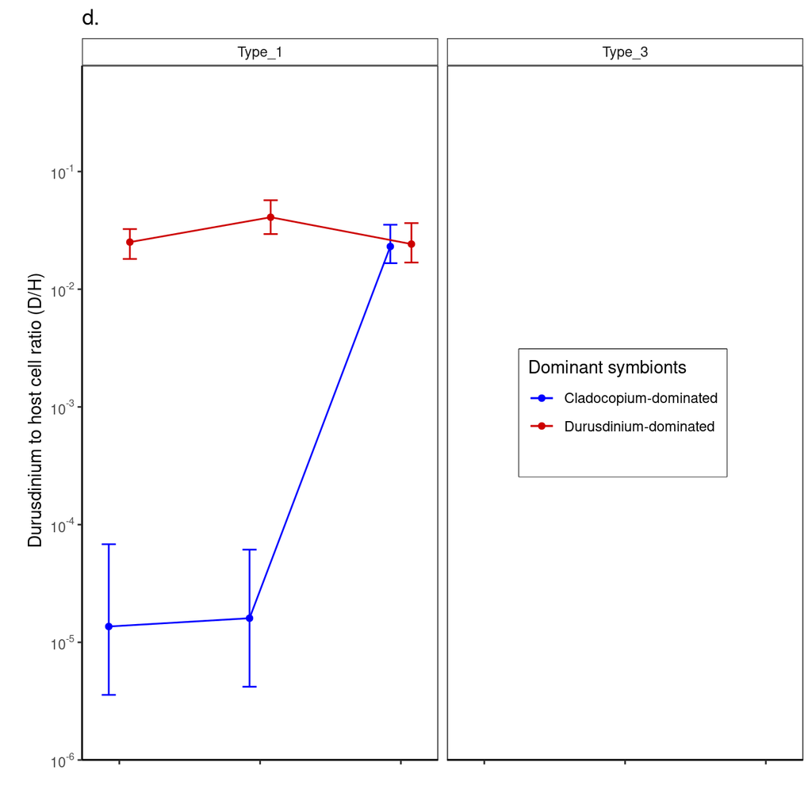

```r
DH_Com2ITS2 <- ggplot(data.Uva, aes (Year.2, logD.SH, colour=factor(D14Dominant))) +  # geom_point(alpha=0.5)+
      ggthe_bw+ ggtitle("d.")+ facet_grid(~ORF) +

      stat_summary(fun.data = "mean_cl_boot",geom = "errorbar", width = 0.2, position=position_dodge(width=0.3))+
      stat_summary(fun.data = "mean_cl_boot",geom = "point", position=position_dodge(width=0.3))+
      stat_summary(fun.y=mean, geom="line", position=position_dodge(width=0.3)) +

      scale_colour_manual(values=c("blue", "red3"),
                        guide = guide_legend(title.position = "top", nrow = 3),
                        name = "Dominant symbionts",
                        labels=c("Cladocopium-dominated", "Durusdinium-dominated"))+
      theme(legend.position=c(0.75,0.5),
            legend.box.background = element_rect(),
            strip.background =element_rect(fill="white"))+

      scale_y_continuous(limits = c(-6, -0.1),
            name="\n Durusdinium to host cell ratio (D/H)",
            labels = (math_format(10^.x)),
            expand = c(0.0, 0)) +
      scale_x_continuous(name="",
                         breaks = c(2014, 2015, 2016),
                        # labels = c(" Aug \n 2014", " Aug \n 2015", " Apr \n 2016"))
                        labels = c(" ", " ", " "))

DH_Com2ITS2
```

```r
DH_LM_ITS2<-lmer(logD.SH ~ Year* DominantITS2 + (1|Colony), data=data.Uva)
    summary(DH_LM_ITS2)
```

```
## Linear mixed model fit by REML. t-tests use Satterthwaite's method [
## lmerModLmerTest]
## Formula: logD.SH ~ Year * DominantITS2 + (1 | Colony)
##    Data: data.Uva
##
## REML criterion at convergence: 62.4
##
## Scaled residuals:
##     Min      1Q  Median      3Q     Max
## -2.1646 -0.5042  0.0345  0.3558  3.7511
##
## Random effects:
##  Groups   Name        Variance Std.Dev.
##  Colony   (Intercept) 0.000    0.0000
##  Residual             0.158    0.3975
## Number of obs: 58, groups:  Colony, 22
##
## Fixed effects:
##                                 Estimate Std. Error       df t value Pr(>|t|)
## (Intercept)                     -4.86573    0.16229 52.00000 -29.981  < 2e-16
## Year15                           0.07049    0.32459 52.00000   0.217    0.829
## Year16                           2.95052    0.42939 52.00000   6.871 7.93e-09
## DominantITS2D1-dominated         3.26614    0.19398 52.00000  16.838  < 2e-16
## Year15:DominantITS2D1-dominated  0.14077    0.35768 52.00000   0.394    0.696
## Year16:DominantITS2D1-dominated -2.96086    0.45076 52.00000  -6.569 2.41e-08
##
## (Intercept)                     ***
## Year15
## Year16                          ***
## DominantITS2D1-dominated        ***
## Year15:DominantITS2D1-dominated
## Year16:DominantITS2D1-dominated ***
## ---
## Signif. codes:  0 '***' 0.001 '**' 0.01 '*' 0.05 '.' 0.1 ' ' 1
##
## Correlation of Fixed Effects:
##             (Intr) Year15 Year16 DITS2D Y15:DI
## Year15      -0.500
## Year16      -0.378  0.189
## DmnnITS2D1- -0.837  0.418  0.316
## Y15:DITS2D1  0.454 -0.907 -0.171 -0.542
## Y16:DITS2D1  0.360 -0.180 -0.953 -0.430  0.233
## optimizer (nloptwrap) convergence code: 0 (OK)
## boundary (singular) fit: see ?isSingular
```

```r
    #step(DH_LM_ITS2)

    DH_I.emmc<-emmeans(DH_LM_ITS2, ~Year*DominantITS2)
    DH_groups_I<-cld(DH_I.emmc)
    DH_groups_I<-as.data.frame(DH_groups_I[complete.cases(DH_groups_I),])
    DH_groups_I<-DH_groups_I[order(DH_groups_I$DominantITS2,DH_groups_I$Year),]
    DH_groups_I
```

|  | Year | DominantITS2 | emmean | SE | df | lower.CL | upper.CL | .group |
| --- | --- | --- | --- | --- | --- | --- | --- | --- |
| 1 | 14 | C1bc-dominated | -4.865729 | 0.16456042 | 52 | -5.195944 | -4.535514 | 1 |
| 2 | 15 | C1bc-dominated | -4.795240 | 0.29072328 | 52 | -5.378619 | -4.211861 | 1 |
| 3 | 16 | C1bc-dominated | -1.915210 | 0.40480917 | 52 | -2.727519 | -1.102901 | 2 |
| 4 | 14 | D1-dominated | -1.599591 | 0.10702753 | 52 | -1.814358 | -1.384825 | 2 |
| 5 | 15 | D1-dominated | -1.388333 | 0.10702753 | 52 | -1.603100 | -1.173567 | 2 |
| 6 | 16 | D1-dominated | -1.609932 | 0.08682543 | 52 | -1.784160 | -1.435704 | 2 |

```r
    #write.csv(DH_groups_I,"Output/DH_I_groups.csv")
```

### Figure 4: qPCR by Pocillopora lineage

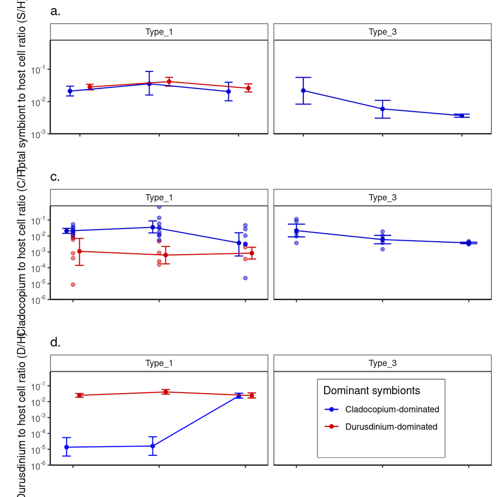

```r
Figure_4<-grid.arrange(SH_2014ComI, CH_Com2ITS2, DH_Com2ITS2,nrow=3)
```

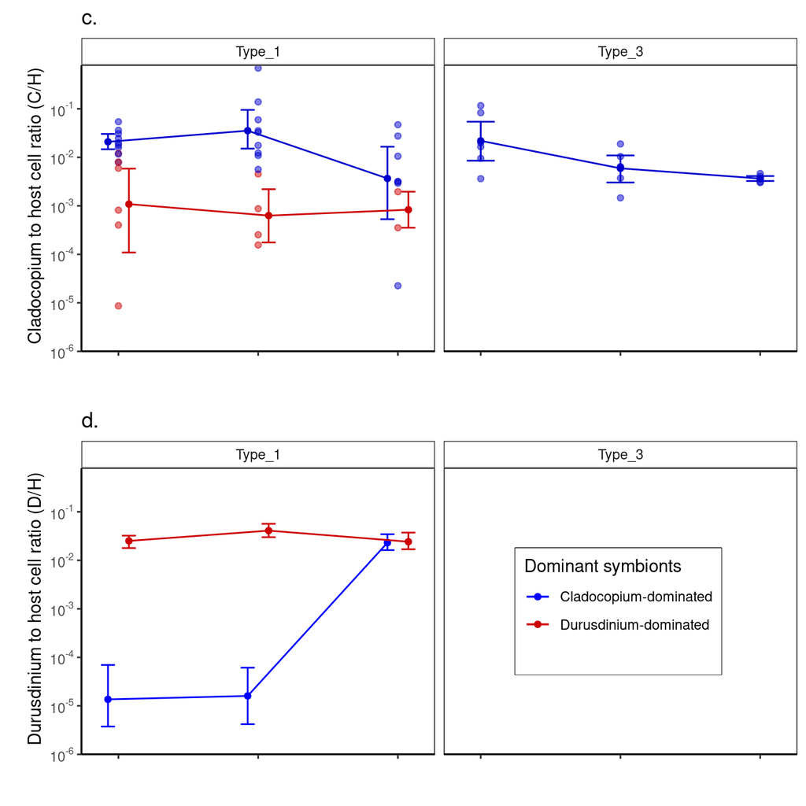

```r
Figure_4_InitailCommunity<-grid.arrange(CH_Com2ITS2, DH_Com2ITS2,nrow=2)
```

```r
# ggsave(file="Outputs/Figure_3c.svg", plot=Figure_3, width=7, height=11)

# ggsave(file="Outputs/Figure_3d.png", plot=Figure_3_InitailCommunity, width=7, height=7)
```

## 10. Supplementary C/H D/H dynamics

Select data

```r
log_Log.data<-data.Uva[,c("Colony","Year.2", "C.SH", "D.SH",
                          "D14Community", "Community","ITS2_14",
                          "ORF", "DominantITS2", "Mortality", "Mor_ITS2")]

log_Log.data<-log_Log.data %>%
  filter(Year.2 != "2015")

log_Log.data$Yr<-as.factor(log_Log.data$Year.2)
log_Log.data$Yr_M<-as.factor(
                            paste(log_Log.data$Yr,
                                  log_Log.data$Mortality,
                                  sep = "_"))

log_Log.data$logC<-log10(log_Log.data$C.SH)
log_Log.data$logD<-log10(log_Log.data$D.SH)
log_Log.data$logC[which(log_Log.data$C.SH==0)] <- -6
log_Log.data$logD[which(log_Log.data$D.SH==0)] <- -6
```

- ITS2-ORF

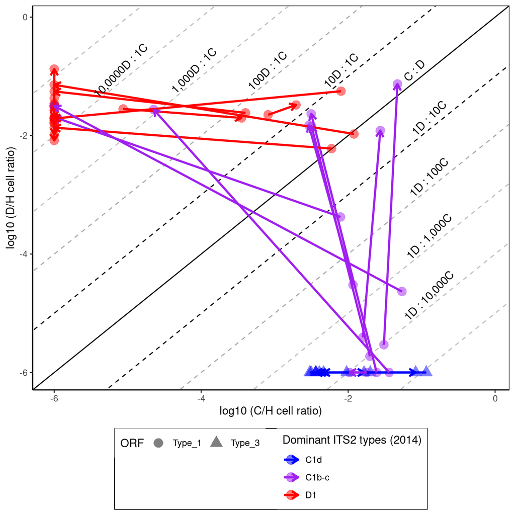

```r
Community_Changes1 <- ggplot (log_Log.data, aes(logC, logD, group=Colony, colour=ITS2_14, shape=ORF)) +

  geom_abline(intercept=0, slope=1, linetype=1, color="black")+
  geom_abline(intercept=-1, slope=1, linetype=2, color="black")+
  geom_abline(intercept=-2, slope=1, linetype=2, color="darkgray")+
  geom_abline(intercept=-3, slope=1, linetype=2, color="gray")+
  geom_abline(intercept=-4, slope=1, linetype=2, color="gray")+
  geom_abline(intercept=-5, slope=1, linetype=2, color="gray")+
  geom_abline(intercept=1, slope=1, linetype=2, color="black")+
  geom_abline(intercept=2, slope=1, linetype=2, color="darkgray")+
  geom_abline(intercept=3, slope=1, linetype=2, color="gray")+
  geom_abline(intercept=4, slope=1, linetype=2, color="gray")+
  geom_abline(intercept=5, slope=1, linetype=2, color="gray")+
  scale_colour_manual(values=c("blue","purple", "red"),
                        guide = guide_legend(title.position = "top", nrow = 3),
                        name = "Dominant ITS2 types (2014)",
                        labels=c("C1d", "C1b-c", "D1"))+

  ggthe_bw + theme(legend.position="bottom",
                    legend.box = "horizontal")+
  scale_x_continuous(limits = c(-6,-0.1), "log10 (C/H cell ratio)")+
  scale_y_continuous(limits = c(-6,-0.1), "log10 (D/H cell ratio)") +

  geom_point(alpha=0.5, size=4) +
  geom_path(size = 1,arrow =
              arrow(type = "open", angle = 30, length = unit(0.1, "inches")))+

 annotate("text", x = c(seq(-5.1, -1.1, by=1)), y = -0.9, label = c(
    "10,0000D : 1C", "1,000D : 1C", "100D : 1C","10D : 1C", "C : D"), angle = 45)+
  annotate("text", x = -0.9, y = c(seq(-4.7, -1.7, by=1)), label = c(
    "1D : 10,000C", "1D : 1,000C", "1D : 100C",  "1D : 10C"), angle = 45)

Community_Changes1
```

```r
#ggsave(file="FigAndrewsFavoriteGraph_ITS2.png", plot=Community_Changes1, width=5.5, height=7.1)
```

- ITS2-Mortality

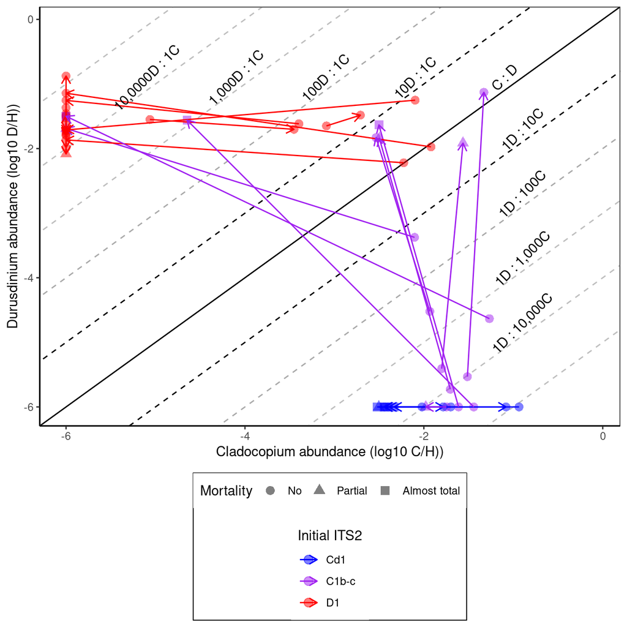

```r
Community_Changes2 <- ggplot (log_Log.data, aes(logC, logD, group=Colony, colour=ITS2_14)) +

  geom_abline(intercept=0, slope=1, linetype=1, color="black")+
  geom_abline(intercept=-1, slope=1, linetype=2, color="black")+
  geom_abline(intercept=-2, slope=1, linetype=2, color="darkgray")+
  geom_abline(intercept=-3, slope=1, linetype=2, color="gray")+
  geom_abline(intercept=-4, slope=1, linetype=2, color="gray")+
  geom_abline(intercept=-5, slope=1, linetype=2, color="gray")+
  geom_abline(intercept=1, slope=1, linetype=2, color="black")+
  geom_abline(intercept=2, slope=1, linetype=2, color="darkgray")+
  geom_abline(intercept=3, slope=1, linetype=2, color="gray")+
  geom_abline(intercept=4, slope=1, linetype=2, color="gray")+
  geom_abline(intercept=5, slope=1, linetype=2, color="gray")+
  scale_colour_manual(values=c("blue","purple", "red"),
        guide = guide_legend(title.position = "top", nrow = 3),
                         name = "Initial ITS2",
                        labels=c("Cd1", "C1b-c", "D1"))+
  #scale_colour_manual(values=c("skyblue1", "blue2", "blue4",
  #                        "darkorchid1","darkorchid3",
  #                        "red1", "red3", "red4"))+

  ggthe_bw +
  theme(legend.position="bottom",
                   legend.box = "vertical")+
  #theme(legend.position="none")+

  scale_x_continuous(limits = c(-6,-0.1),
                     "Cladocopium abundance (log10 C/H))")+
  scale_y_continuous(limits = c(-6,-0.1),
                     "Durusdinium abundance (log10 D/H))") +
  geom_point(aes(shape=Mortality),
             alpha=0.5, size=3) +
  geom_path(size = 0.5 , arrow =
             arrow(type = "open", angle = 30,
                  length = unit(0.1, "inches")))+

 annotate("text", x = c(seq(-5.1, -1.1, by=1)), y = -0.9, label = c(
    "10,0000D : 1C", "1,000D : 1C", "100D : 1C","10D : 1C", "C : D"), angle = 45)+
  annotate("text", x = -0.9, y = c(seq(-4.7, -1.7, by=1)), label = c(
    "1D : 10,000C", "1D : 1,000C", "1D : 100C",  "1D : 10C"), angle = 45)

Community_Changes2
```

```r
#ggsave(file="LogLog_labels.svg", plot=Community_Changes2, width=5.5, height=6)
```

- Colony

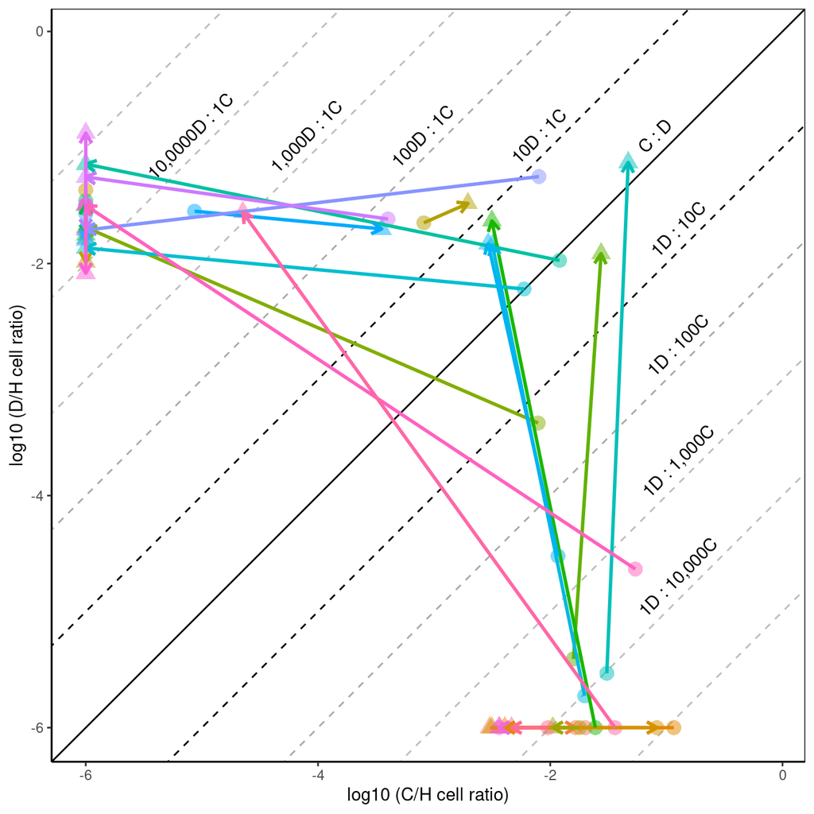

```r
Community_Changes3 <- ggplot (log_Log.data, aes(logC, logD, group=Colony, colour=Colony)) +

  geom_abline(intercept=0, slope=1, linetype=1, color="black")+
  geom_abline(intercept=-1, slope=1, linetype=2, color="black")+
  geom_abline(intercept=-2, slope=1, linetype=2, color="darkgray")+
  geom_abline(intercept=-3, slope=1, linetype=2, color="gray")+
  geom_abline(intercept=-4, slope=1, linetype=2, color="gray")+
  geom_abline(intercept=-5, slope=1, linetype=2, color="gray")+
  geom_abline(intercept=1, slope=1, linetype=2, color="black")+
  geom_abline(intercept=2, slope=1, linetype=2, color="darkgray")+
  geom_abline(intercept=3, slope=1, linetype=2, color="gray")+
  geom_abline(intercept=4, slope=1, linetype=2, color="gray")+
  geom_abline(intercept=5, slope=1, linetype=2, color="gray")+
  #scale_colour_manual(values=c("blue","purple", "red"),
   #                     guide = guide_legend(title.position = "top", nrow = 3),
    #                    name = "Detected symbionts (2014)",
     #                   labels=c("Cladocopium", "Mixed", "Durusdinium"))+

  ggthe_bw + theme(legend.position="none")+
  scale_x_continuous(limits = c(-6,-0.1), "log10 (C/H cell ratio)")+
  scale_y_continuous(limits = c(-6,-0.1), "log10 (D/H cell ratio)") +

  geom_point(aes(shape=Yr), alpha=0.5, size=4) +
  geom_path(size = 1,arrow =
              arrow(type = "open", angle = 30, length = unit(0.1, "inches")))+

  annotate("text", x = c(seq(-5.1, -1.1, by=1)), y = -0.9, label = c(
    "10,0000D : 1C", "1,000D : 1C", "100D : 1C","10D : 1C", "C : D"), angle = 45)+
  annotate("text", x = -0.9, y = c(seq(-4.7, -1.7, by=1)), label = c(
    "1D : 10,000C", "1D : 1,000C", "1D : 100C",  "1D : 10C"), angle = 45)

Community_Changes3
```

```r
# ggsave(file="LogLog_Colony.svg", plot=Community_Changes3, width=6, height=6)
```

## 5c. Changes in the number of colonies dominated by each genus considering mortality

- Fisher test including initially (Aug 2014) 50/50 colonies. Both colonies were placed in the D-dominated category to be conservative.

```r
# Only type 1 colonies (n=23)

Input =("
Year    C     D
2014    9    14
2016    2    18
")

Matriz <- as.matrix(read.table(textConnection(Input),
                               header=TRUE,
                               row.names=1))
fisher.test(Matriz,
            alternative="two.sided")
```

```
##
##  Fisher's Exact Test for Count Data
##
## data:  Matriz
## p-value = 0.03936
## alternative hypothesis: true odds ratio is not equal to 1
## 95 percent confidence interval:
##   0.9354645 61.0268633
## sample estimates:
## odds ratio
##   5.560207
```

```r
# Type 1 and type 3 colonies

Input =("
Year    C     D
2014    15    14
2016    4     18
")

Matriz <- as.matrix(read.table(textConnection(Input),
                               header=TRUE,
                               row.names=1))
fisher.test(Matriz,
            alternative="two.sided")
```

```
##
##  Fisher's Exact Test for Count Data
##
## data:  Matriz
## p-value = 0.01988
## alternative hypothesis: true odds ratio is not equal to 1
## 95 percent confidence interval:
##   1.145585 23.762126
## sample estimates:
## odds ratio
##   4.670456
```

```r
# Spp changes

Input =("
Year    I     II
2014    23    6
2016    20    2
")

Matriz <- as.matrix(read.table(textConnection(Input),
                               header=TRUE,
                               row.names=1))
fisher.test(Matriz,
            alternative="two.sided")
```

```
##
##  Fisher's Exact Test for Count Data
##
## data:  Matriz
## p-value = 0.4399
## alternative hypothesis: true odds ratio is not equal to 1
## 95 percent confidence interval:
##  0.03477518 2.50826671
## sample estimates:
## odds ratio
##  0.3901317
```